# val-6-models

# model= ridge filter= 0.05 outcome= lbo clin feat= g3

## Internal validation

|  | Accuracy | Sensitivity | Specificity | AUC |
| --- | --- | --- | --- | --- |
| metric.mean.df | 0.757 | 0.669 | 0.815 | 0.837 |
| metric.quantiles | (0.723-0.793) | (0.594-0.752) | (0.775-0.84) | (0.807-0.861) |

|  | NPO-reference | Live_birth-reference |
| --- | --- | --- |
| NPO-prediction | 318 | 86 |
| Live_birth-prediction | 72 | 174 |

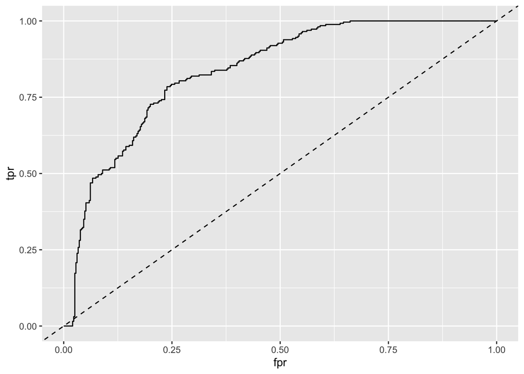

## External validation

|  | Accuracy | Sensitivity | Specificity | AUC |
| --- | --- | --- | --- | --- |
| metric.mean.df | 0.561 | 0.435 | 0.75 | 0.742 |
| metric.quantiles | (0.552-0.57) | (0.42-0.45) | (0.75-0.75) | (0.736-0.75) |

|  | NPO-reference | Live_birth-reference |
| --- | --- | --- |
| NPO-prediction | 300 | 339 |
| Live_birth-prediction | 100 | 261 |

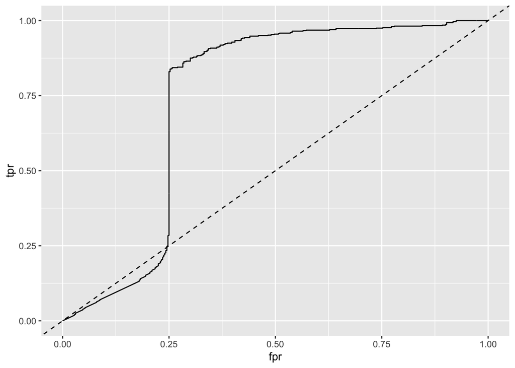

# model= ridge filter= 0.05 outcome= lbo clin feat= g3+age

## Internal validation

|  | Accuracy | Sensitivity | Specificity | AUC |
| --- | --- | --- | --- | --- |
| metric.mean.df | 0.768 | 0.658 | 0.841 | 0.836 |
| metric.quantiles | (0.715-0.824) | (0.615-0.761) | (0.781-0.892) | (0.806-0.857) |

|  | NPO-reference | Live_birth-reference |
| --- | --- | --- |
| NPO-prediction | 328 | 89 |
| Live_birth-prediction | 62 | 171 |

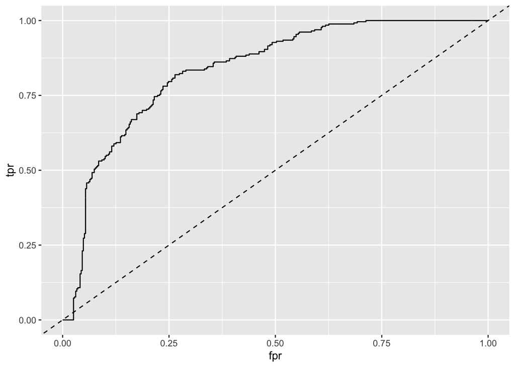

## External validation

|  | Accuracy | Sensitivity | Specificity | AUC |
| --- | --- | --- | --- | --- |
| metric.mean.df | 0.564 | 0.44 | 0.75 | 0.725 |
| metric.quantiles | (0.54-0.58) | (0.4-0.467) | (0.75-0.75) | (0.718-0.733) |

|  | NPO-reference | Live_birth-reference |
| --- | --- | --- |
| NPO-prediction | 300 | 336 |
| Live_birth-prediction | 100 | 264 |

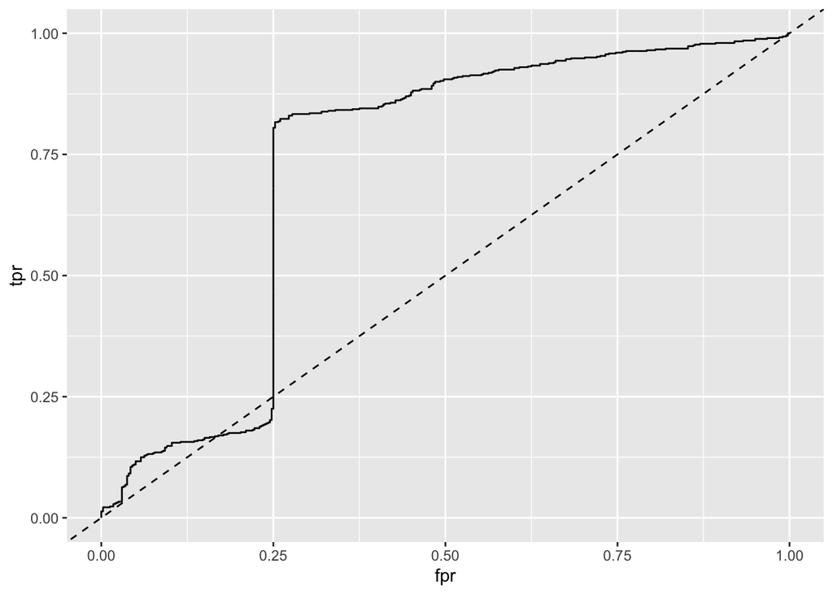

# model= ridge filter= 0.1 outcome= lbo clin feat= none

## Internal validation

|  | Accuracy | Sensitivity | Specificity | AUC |
| --- | --- | --- | --- | --- |
| metric.mean.df | 0.749 | 0.577 | 0.864 | 0.78 |
| metric.quantiles | (0.715-0.769) | (0.509-0.615) | (0.846-0.892) | (0.75-0.801) |

|  | NPO-reference | Live_birth-reference |
| --- | --- | --- |
| NPO-prediction | 337 | 110 |
| Live_birth-prediction | 53 | 150 |

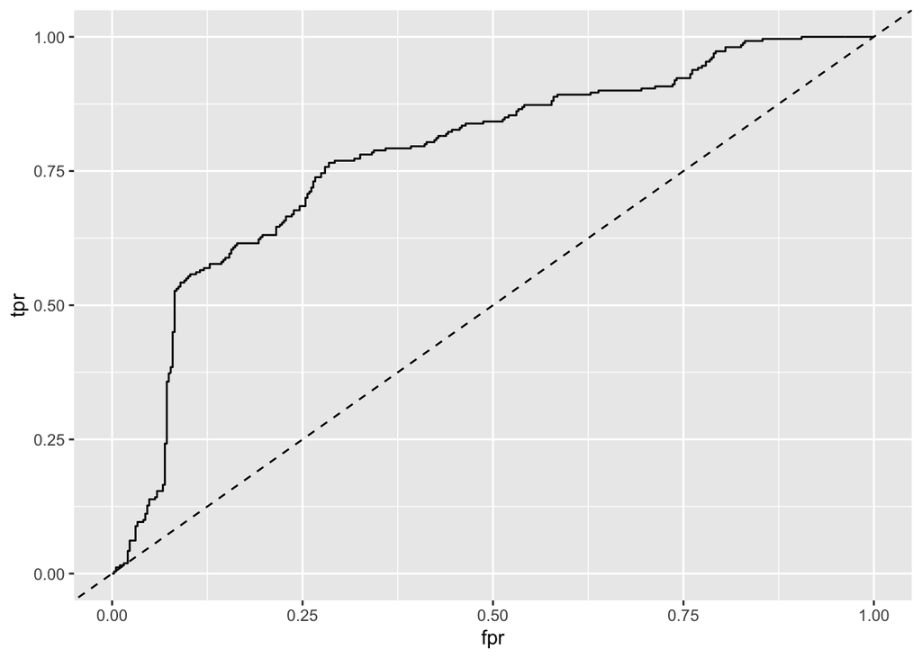

## External validation

|  | Accuracy | Sensitivity | Specificity | AUC |
| --- | --- | --- | --- | --- |
| metric.mean.df | 0.794 | 0.823 | 0.75 | 0.748 |
| metric.quantiles | (0.772-0.8) | (0.787-0.833) | (0.75-0.75) | (0.74-0.752) |

|  | NPO-reference | Live_birth-reference |
| --- | --- | --- |
| NPO-prediction | 300 | 106 |
| Live_birth-prediction | 100 | 494 |

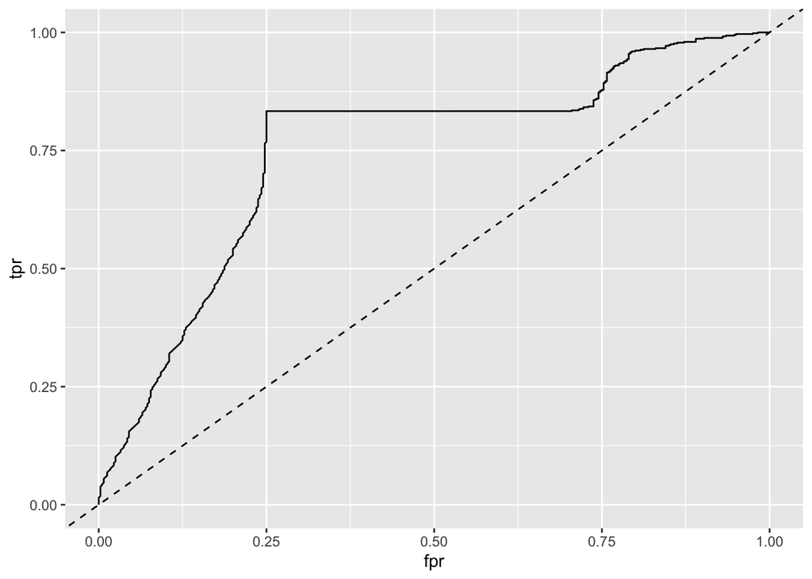

# model= ridge filter= 0.1 outcome= lbo clin feat= age

## Internal validation

|  | Accuracy | Sensitivity | Specificity | AUC |
| --- | --- | --- | --- | --- |
| metric.mean.df | 0.729 | 0.573 | 0.833 | 0.769 |
| metric.quantiles | (0.696-0.778) | (0.538-0.645) | (0.775-0.892) | (0.735-0.803) |

|  | NPO-reference | Live_birth-reference |
| --- | --- | --- |
| NPO-prediction | 325 | 111 |
| Live_birth-prediction | 65 | 149 |

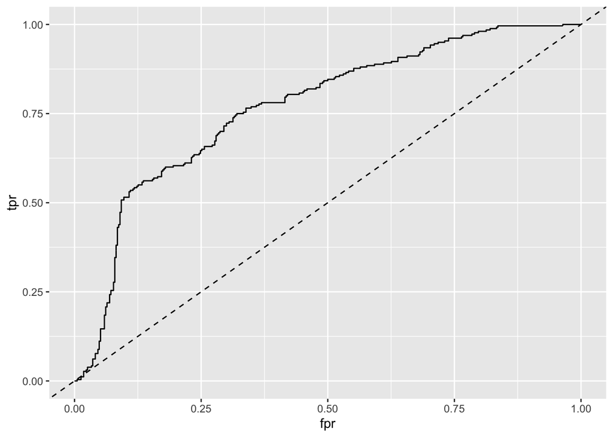

## External validation

|  | Accuracy | Sensitivity | Specificity | AUC |
| --- | --- | --- | --- | --- |
| metric.mean.df | 0.748 | 0.747 | 0.75 | 0.752 |
| metric.quantiles | (0.732-0.768) | (0.72-0.78) | (0.75-0.75) | (0.748-0.757) |

|  | NPO-reference | Live_birth-reference |
| --- | --- | --- |
| NPO-prediction | 300 | 152 |
| Live_birth-prediction | 100 | 448 |

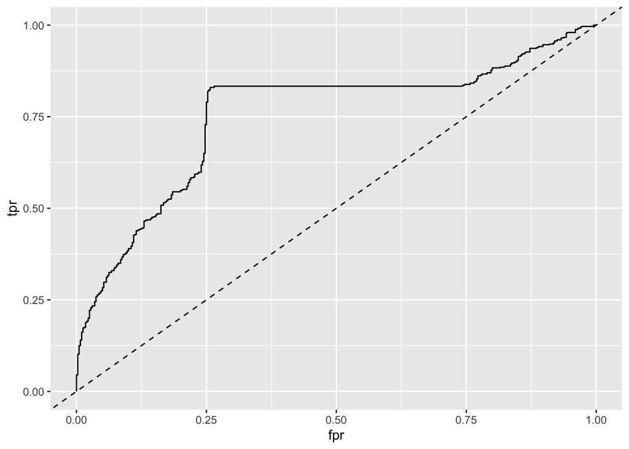

# model= ridge filter= 0.1 outcome= lbo clin feat= g1+g2+g3

## Internal validation

|  | Accuracy | Sensitivity | Specificity | AUC |
| --- | --- | --- | --- | --- |
| metric.mean.df | 0.731 | 0.585 | 0.828 | 0.784 |
| metric.quantiles | (0.708-0.774) | (0.538-0.645) | (0.795-0.866) | (0.768-0.805) |

|  | NPO-reference | Live_birth-reference |
| --- | --- | --- |
| NPO-prediction | 323 | 108 |
| Live_birth-prediction | 67 | 152 |

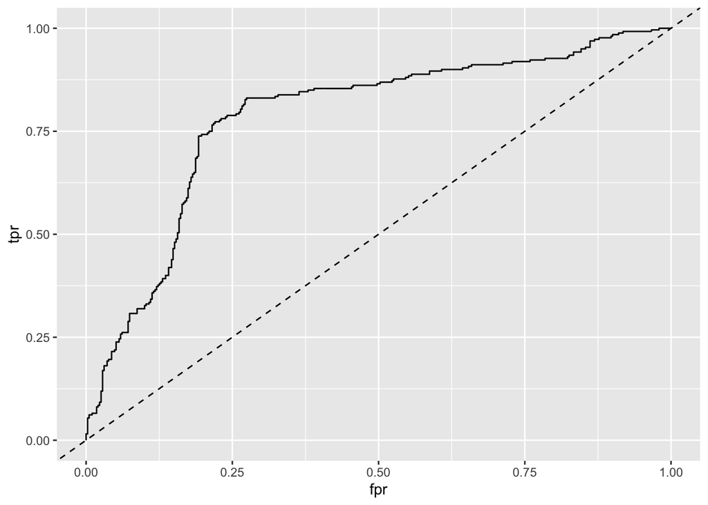

## External validation

|  | Accuracy | Sensitivity | Specificity | AUC |
| --- | --- | --- | --- | --- |
| metric.mean.df | 0.667 | 0.62 | 0.737 | 0.722 |
| metric.quantiles | (0.652-0.688) | (0.587-0.646) | (0.725-0.75) | (0.718-0.727) |

|  | NPO-reference | Live_birth-reference |
| --- | --- | --- |
| NPO-prediction | 295 | 228 |
| Live_birth-prediction | 105 | 372 |

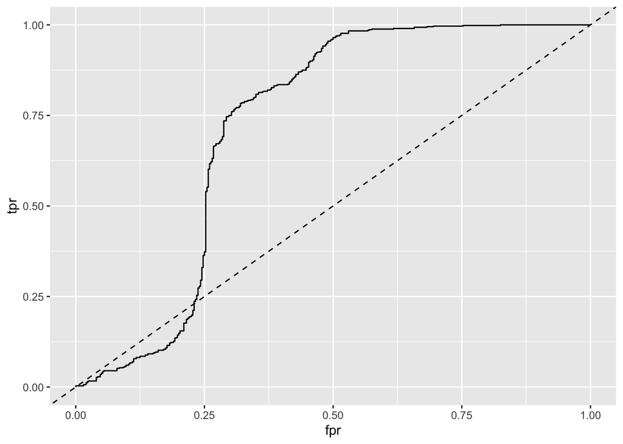

# model= ridge filter= 0.1 outcome= lbo clin feat= g1+g2+g3+age

## Internal validation

|  | Accuracy | Sensitivity | Specificity | AUC |
| --- | --- | --- | --- | --- |
| metric.mean.df | 0.725 | 0.558 | 0.836 | 0.781 |
| metric.quantiles | (0.696-0.738) | (0.5-0.615) | (0.821-0.846) | (0.754-0.804) |

|  | NPO-reference | Live_birth-reference |
| --- | --- | --- |
| NPO-prediction | 326 | 115 |
| Live_birth-prediction | 64 | 145 |

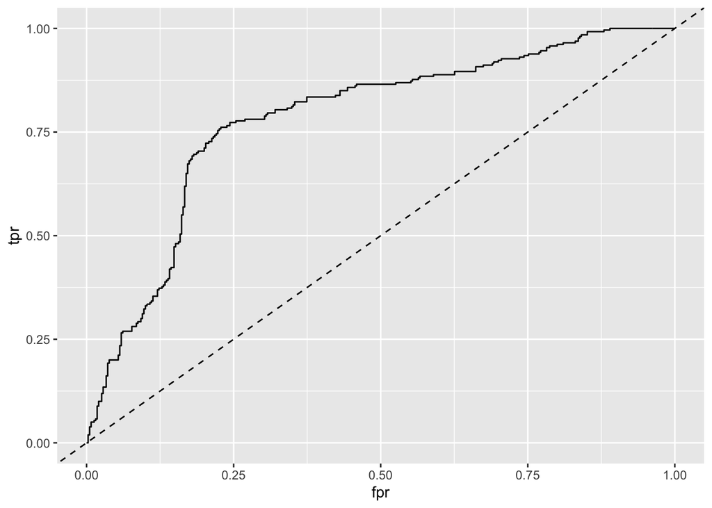

## External validation

|  | Accuracy | Sensitivity | Specificity | AUC |
| --- | --- | --- | --- | --- |
| metric.mean.df | 0.635 | 0.583 | 0.713 | 0.712 |
| metric.quantiles | (0.612-0.65) | (0.554-0.6) | (0.7-0.744) | (0.709-0.718) |

|  | NPO-reference | Live_birth-reference |
| --- | --- | --- |
| NPO-prediction | 285 | 250 |
| Live_birth-prediction | 115 | 350 |

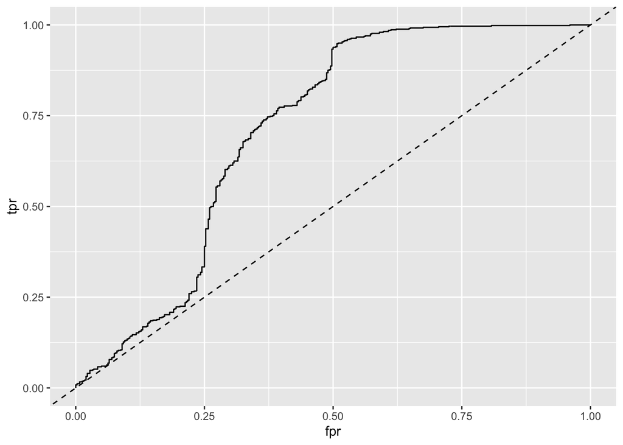

# model= ridge filter= 0.1 outcome= lbo clin feat= g3

## Internal validation

|  | Accuracy | Sensitivity | Specificity | AUC |
| --- | --- | --- | --- | --- |
| metric.mean.df | 0.794 | 0.746 | 0.826 | 0.787 |
| metric.quantiles | (0.769-0.815) | (0.701-0.799) | (0.801-0.846) | (0.767-0.81) |

|  | NPO-reference | Live_birth-reference |
| --- | --- | --- |
| NPO-prediction | 322 | 66 |
| Live_birth-prediction | 68 | 194 |

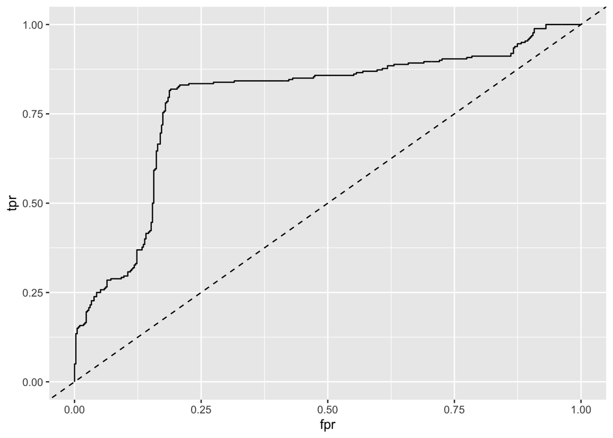

## External validation

|  | Accuracy | Sensitivity | Specificity | AUC |
| --- | --- | --- | --- | --- |
| metric.mean.df | 0.729 | 0.743 | 0.708 | 0.717 |
| metric.quantiles | (0.712-0.748) | (0.717-0.78) | (0.681-0.744) | (0.711-0.723) |

|  | NPO-reference | Live_birth-reference |
| --- | --- | --- |
| NPO-prediction | 283 | 154 |
| Live_birth-prediction | 117 | 446 |

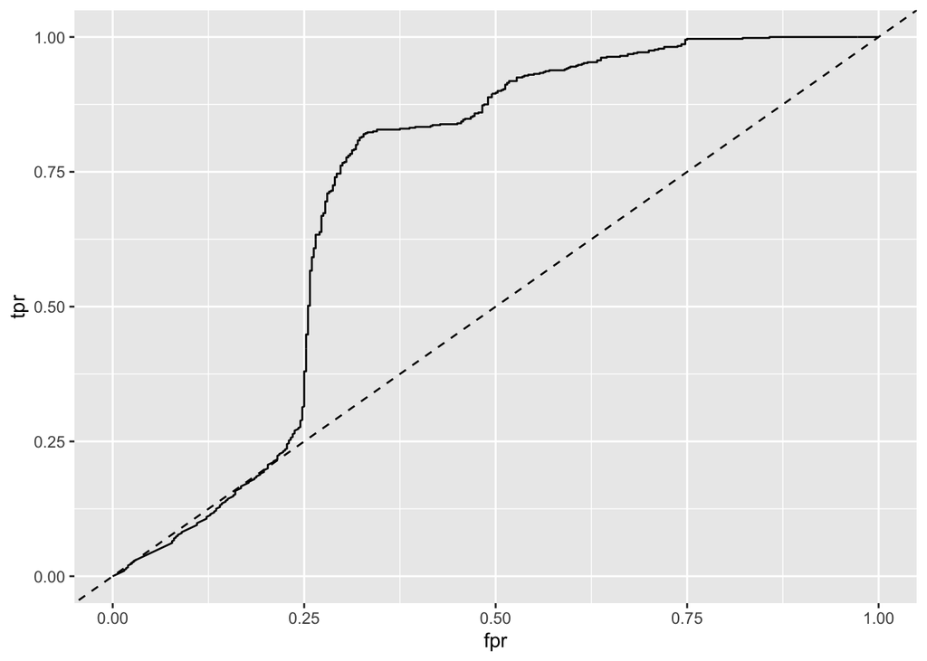

# model= ridge filter= 0.1 outcome= lbo clin feat= g3+age

## Internal validation

|  | Accuracy | Sensitivity | Specificity | AUC |
| --- | --- | --- | --- | --- |
| metric.mean.df | 0.772 | 0.696 | 0.823 | 0.785 |
| metric.quantiles | (0.738-0.824) | (0.624-0.79) | (0.795-0.846) | (0.761-0.808) |

|  | NPO-reference | Live_birth-reference |
| --- | --- | --- |
| NPO-prediction | 321 | 79 |
| Live_birth-prediction | 69 | 181 |

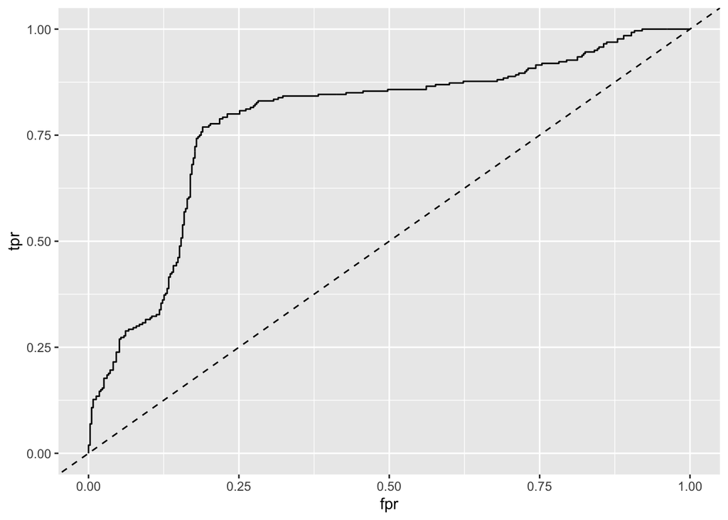

## External validation

|  | Accuracy | Sensitivity | Specificity | AUC |
| --- | --- | --- | --- | --- |
| metric.mean.df | 0.685 | 0.705 | 0.655 | 0.69 |
| metric.quantiles | (0.654-0.71) | (0.67-0.733) | (0.625-0.675) | (0.684-0.698) |

|  | NPO-reference | Live_birth-reference |
| --- | --- | --- |
| NPO-prediction | 262 | 177 |
| Live_birth-prediction | 138 | 423 |

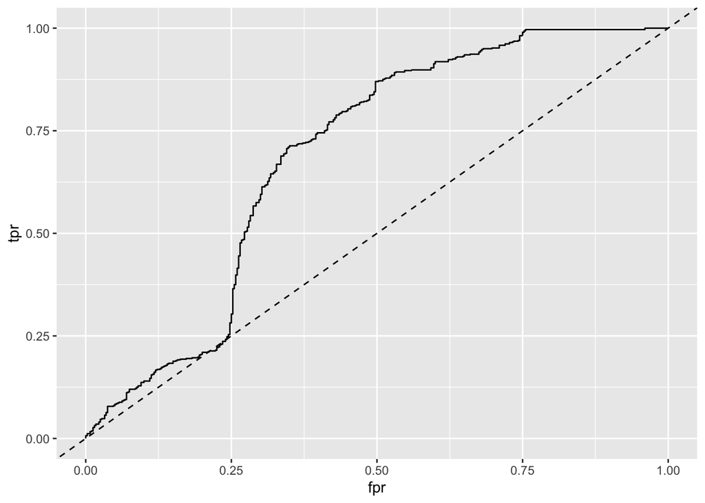

# model= rf filter= 0.05 outcome= hCG clin feat= none

## Internal validation

|  | Accuracy | Sensitivity | Specificity | AUC |
| --- | --- | --- | --- | --- |
| metric.mean.df | 0.726 | 0.719 | 0.733 | 0.821 |
| metric.quantiles | (0.68-0.778) | (0.615-0.823) | (0.673-0.781) | (0.783-0.849) |

|  | Negative-reference | Positive-reference |
| --- | --- | --- |
| Negative-prediction | 242 | 90 |
| Positive-prediction | 88 | 230 |

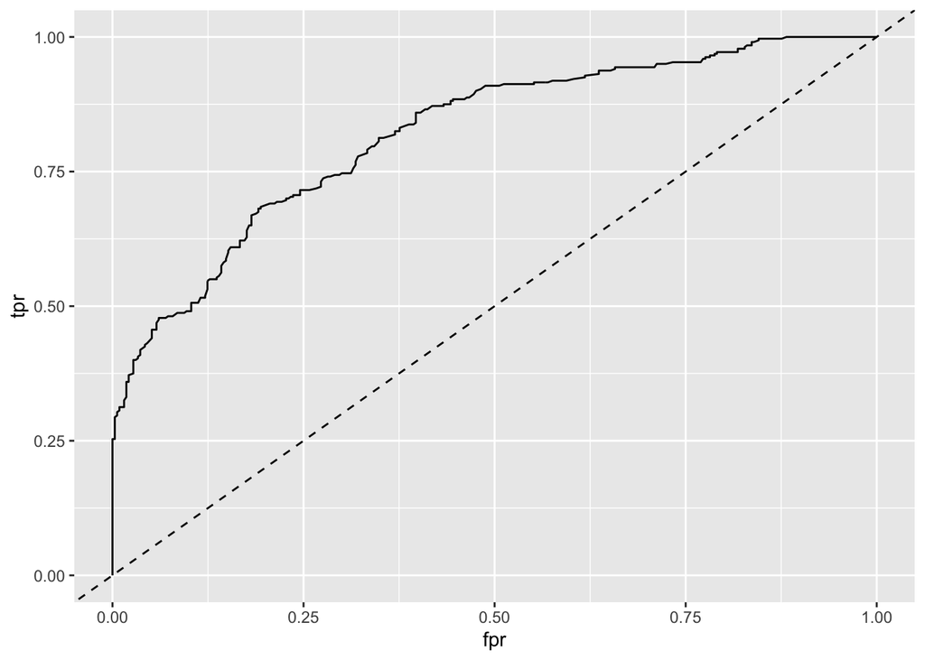

## External validation

|  | Accuracy | Sensitivity | Specificity | AUC |
| --- | --- | --- | --- | --- |
| metric.mean.df | 0.721 | 0.815 | 0.58 | 0.735 |
| metric.quantiles | (0.71-0.746) | (0.8-0.833) | (0.55-0.619) | (0.726-0.745) |

|  | Negative-reference | Positive-reference |
| --- | --- | --- |
| Negative-prediction | 232 | 111 |
| Positive-prediction | 168 | 489 |

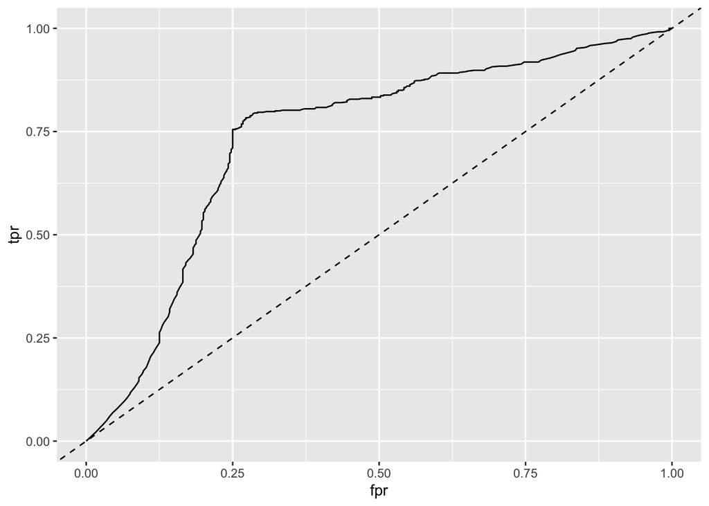

# model= rf filter= 0.05 outcome= hCG clin feat= age

## Internal validation

|  | Accuracy | Sensitivity | Specificity | AUC |
| --- | --- | --- | --- | --- |
| metric.mean.df | 0.726 | 0.728 | 0.724 | 0.814 |
| metric.quantiles | (0.68-0.781) | (0.663-0.812) | (0.667-0.758) | (0.789-0.838) |

|  | Negative-reference | Positive-reference |
| --- | --- | --- |
| Negative-prediction | 239 | 87 |
| Positive-prediction | 91 | 233 |

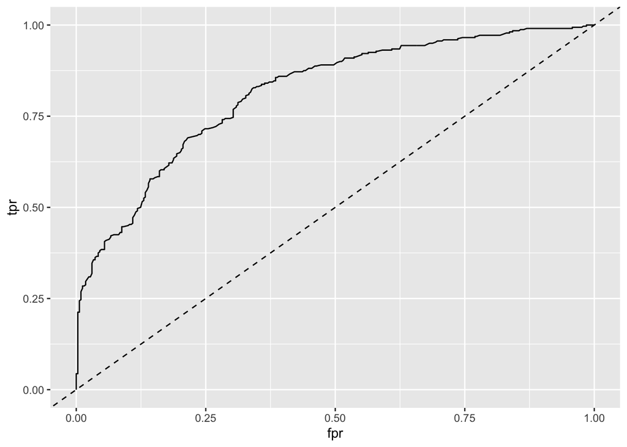

## External validation

|  | Accuracy | Sensitivity | Specificity | AUC |
| --- | --- | --- | --- | --- |
| metric.mean.df | 0.666 | 0.722 | 0.583 | 0.683 |
| metric.quantiles | (0.642-0.68) | (0.7-0.75) | (0.55-0.625) | (0.673-0.695) |

|  | Negative-reference | Positive-reference |
| --- | --- | --- |
| Negative-prediction | 233 | 167 |
| Positive-prediction | 167 | 433 |

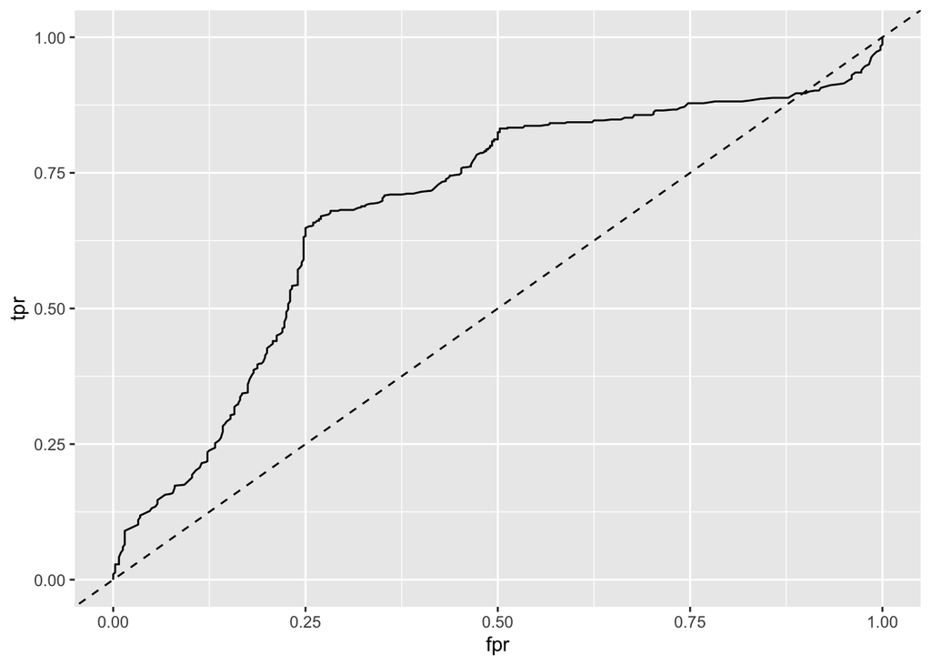

# model= rf filter= 0.05 outcome= hCG clin feat= g1+g2+g3

## Internal validation

|  | Accuracy | Sensitivity | Specificity | AUC |
| --- | --- | --- | --- | --- |
| metric.mean.df | 0.775 | 0.778 | 0.773 | 0.841 |
| metric.quantiles | (0.715-0.812) | (0.688-0.844) | (0.727-0.818) | (0.82-0.866) |

|  | Negative-reference | Positive-reference |
| --- | --- | --- |
| Negative-prediction | 255 | 71 |
| Positive-prediction | 75 | 249 |

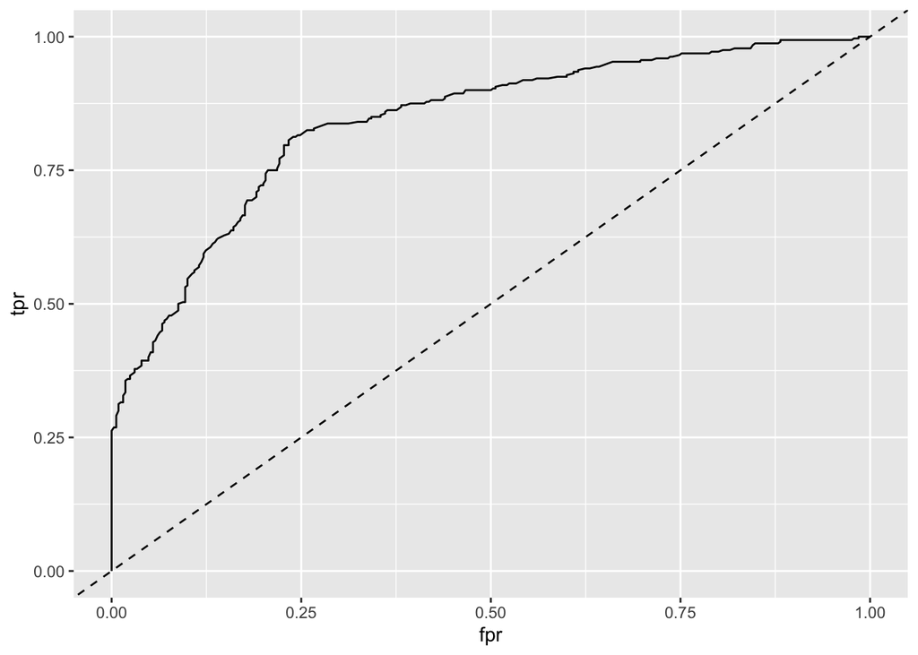

## External validation

|  | Accuracy | Sensitivity | Specificity | AUC |
| --- | --- | --- | --- | --- |
| metric.mean.df | 0.749 | 0.828 | 0.63 | 0.809 |
| metric.quantiles | (0.74-0.766) | (0.817-0.833) | (0.6-0.669) | (0.794-0.82) |

|  | Negative-reference | Positive-reference |
| --- | --- | --- |
| Negative-prediction | 252 | 103 |
| Positive-prediction | 148 | 497 |

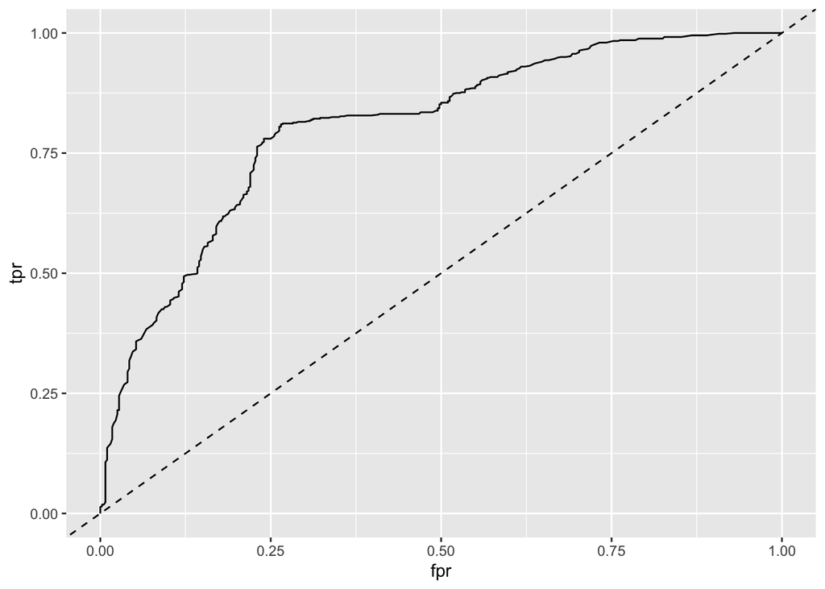

# model= rf filter= 0.05 outcome= hCG clin feat= g1+g2+g3+age

## Internal validation

|  | Accuracy | Sensitivity | Specificity | AUC |
| --- | --- | --- | --- | --- |
| metric.mean.df | 0.765 | 0.756 | 0.773 | 0.813 |
| metric.quantiles | (0.742-0.797) | (0.719-0.805) | (0.734-0.818) | (0.783-0.839) |

|  | Negative-reference | Positive-reference |
| --- | --- | --- |
| Negative-prediction | 255 | 78 |
| Positive-prediction | 75 | 242 |

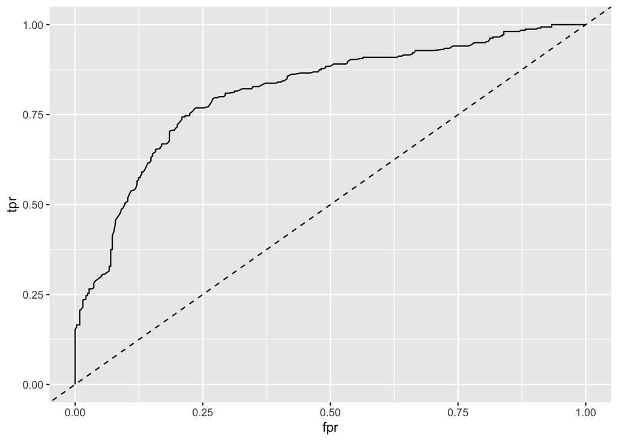

## External validation

|  | Accuracy | Sensitivity | Specificity | AUC |
| --- | --- | --- | --- | --- |
| metric.mean.df | 0.726 | 0.805 | 0.607 | 0.745 |
| metric.quantiles | (0.7-0.748) | (0.783-0.83) | (0.556-0.65) | (0.732-0.759) |

|  | Negative-reference | Positive-reference |
| --- | --- | --- |
| Negative-prediction | 243 | 117 |
| Positive-prediction | 157 | 483 |

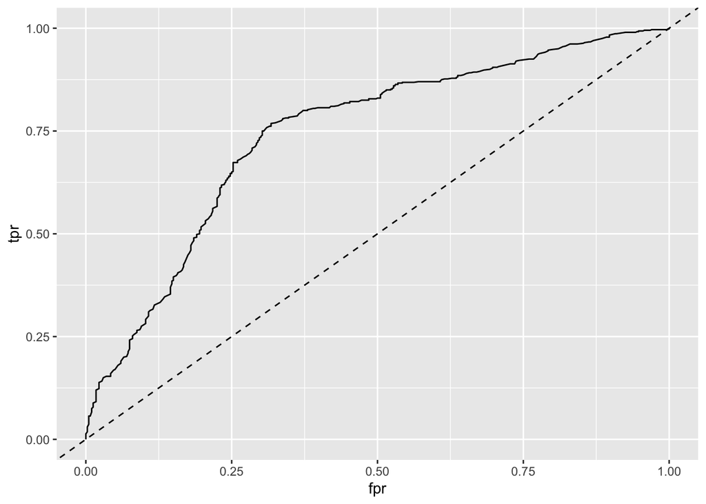

# model= rf filter= 0.05 outcome= hCG clin feat= g3

## Internal validation

|  | Accuracy | Sensitivity | Specificity | AUC |
| --- | --- | --- | --- | --- |
| metric.mean.df | 0.765 | 0.8 | 0.73 | 0.841 |
| metric.quantiles | (0.738-0.8) | (0.75-0.844) | (0.697-0.758) | (0.825-0.863) |

|  | Negative-reference | Positive-reference |
| --- | --- | --- |
| Negative-prediction | 241 | 64 |
| Positive-prediction | 89 | 256 |

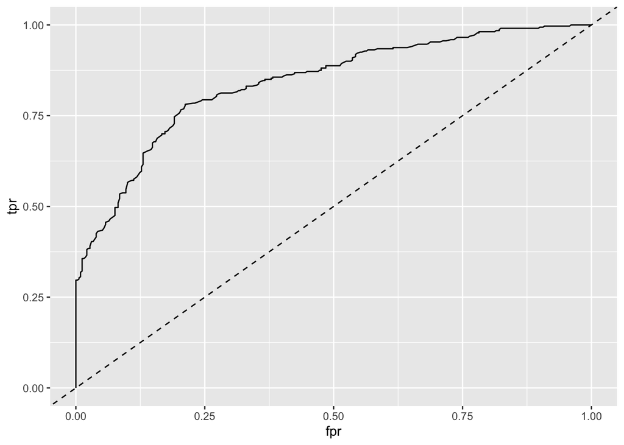

## External validation

|  | Accuracy | Sensitivity | Specificity | AUC |
| --- | --- | --- | --- | --- |
| metric.mean.df | 0.732 | 0.817 | 0.605 | 0.757 |
| metric.quantiles | (0.704-0.75) | (0.8-0.833) | (0.556-0.65) | (0.749-0.767) |

|  | Negative-reference | Positive-reference |
| --- | --- | --- |
| Negative-prediction | 242 | 110 |
| Positive-prediction | 158 | 490 |

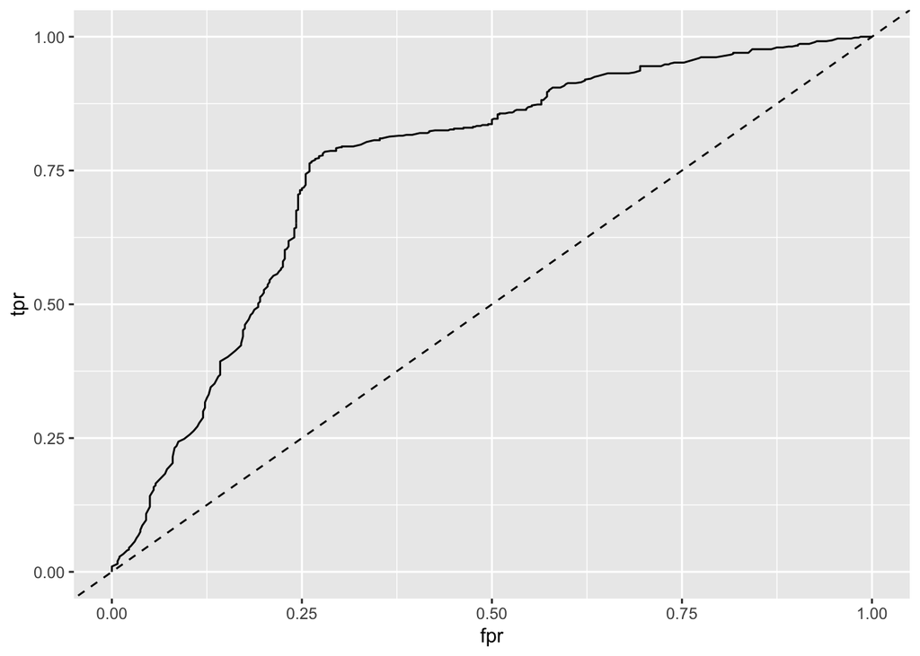

# model= rf filter= 0.05 outcome= hCG clin feat= g3+age

## Internal validation

|  | Accuracy | Sensitivity | Specificity | AUC |
| --- | --- | --- | --- | --- |
| metric.mean.df | 0.757 | 0.753 | 0.761 | 0.814 |
| metric.quantiles | (0.711-0.808) | (0.695-0.812) | (0.697-0.811) | (0.796-0.842) |

|  | Negative-reference | Positive-reference |
| --- | --- | --- |
| Negative-prediction | 251 | 79 |
| Positive-prediction | 79 | 241 |

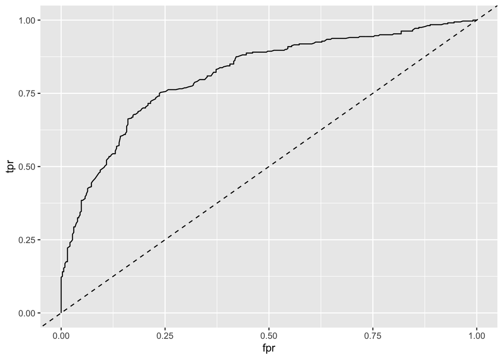

## External validation

|  | Accuracy | Sensitivity | Specificity | AUC |
| --- | --- | --- | --- | --- |
| metric.mean.df | 0.675 | 0.738 | 0.58 | 0.704 |
| metric.quantiles | (0.66-0.706) | (0.7-0.78) | (0.531-0.619) | (0.697-0.713) |

|  | Negative-reference | Positive-reference |
| --- | --- | --- |
| Negative-prediction | 232 | 157 |
| Positive-prediction | 168 | 443 |

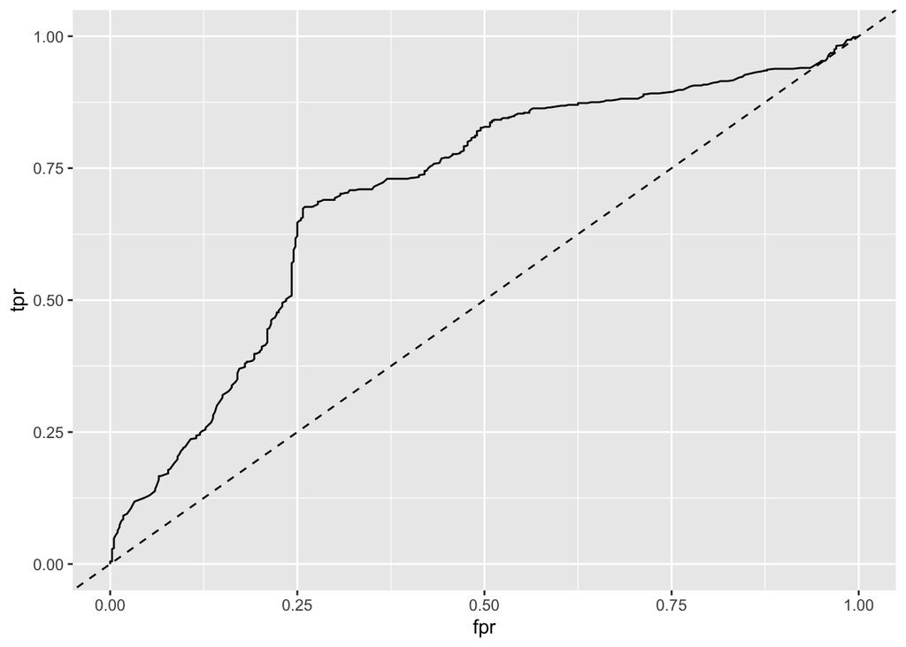

# model= rf filter= 0.1 outcome= hCG clin feat= none

## Internal validation

|  | Accuracy | Sensitivity | Specificity | AUC |
| --- | --- | --- | --- | --- |
| metric.mean.df | 0.8 | 0.784 | 0.815 | 0.867 |
| metric.quantiles | (0.757-0.839) | (0.719-0.844) | (0.764-0.848) | (0.827-0.901) |

|  | Negative-reference | Positive-reference |
| --- | --- | --- |
| Negative-prediction | 269 | 69 |
| Positive-prediction | 61 | 251 |

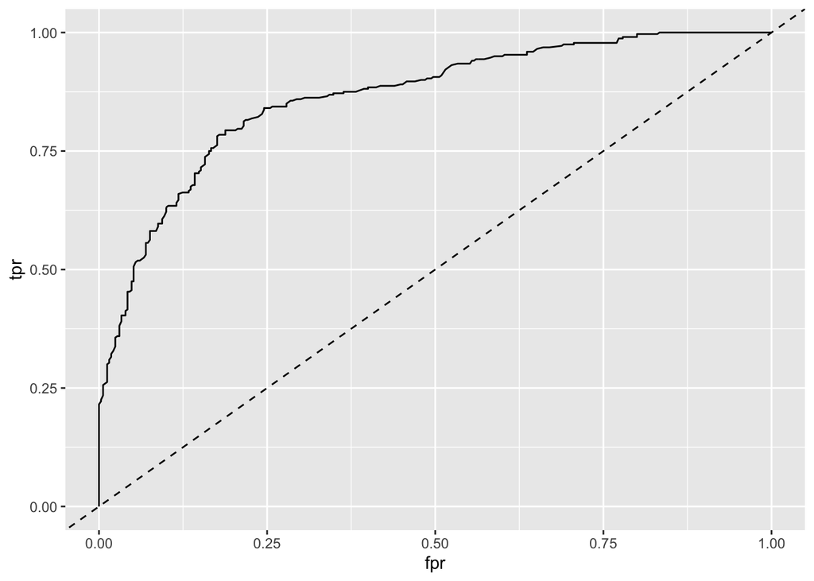

## External validation

|  | Accuracy | Sensitivity | Specificity | AUC |
| --- | --- | --- | --- | --- |
| metric.mean.df | 0.768 | 0.828 | 0.677 | 0.755 |
| metric.quantiles | (0.752-0.79) | (0.817-0.833) | (0.65-0.725) | (0.742-0.765) |

|  | Negative-reference | Positive-reference |
| --- | --- | --- |
| Negative-prediction | 271 | 103 |
| Positive-prediction | 129 | 497 |

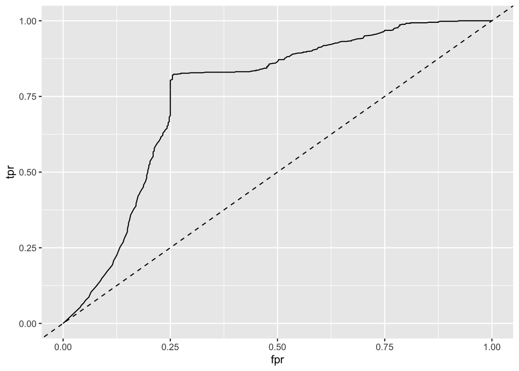

# model= rf filter= 0.1 outcome= hCG clin feat= age

## Internal validation

|  | Accuracy | Sensitivity | Specificity | AUC |
| --- | --- | --- | --- | --- |
| metric.mean.df | 0.749 | 0.719 | 0.779 | 0.835 |
| metric.quantiles | (0.699-0.785) | (0.656-0.774) | (0.704-0.842) | (0.793-0.868) |

|  | Negative-reference | Positive-reference |
| --- | --- | --- |
| Negative-prediction | 257 | 90 |
| Positive-prediction | 73 | 230 |

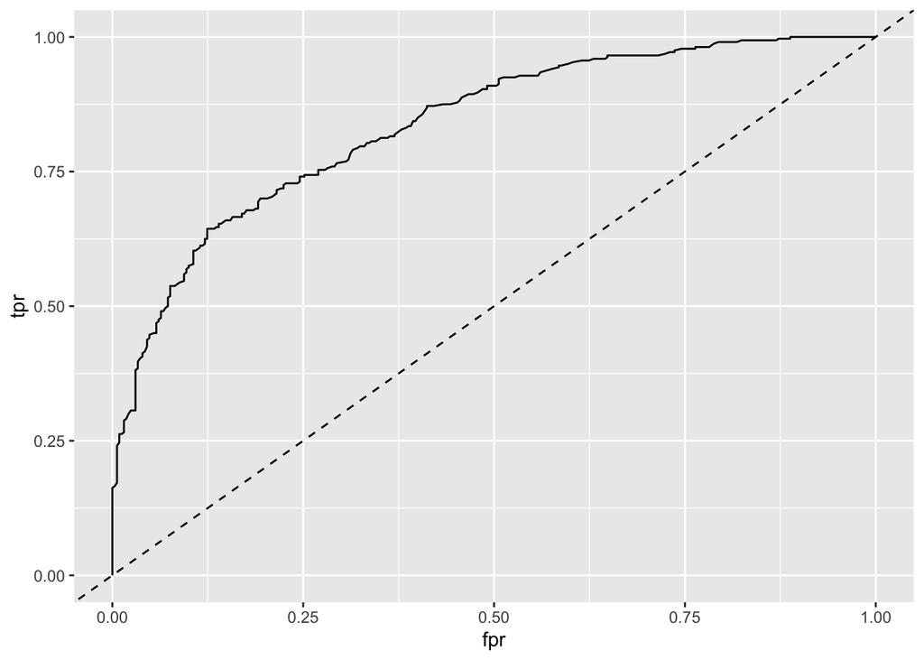

## External validation

|  | Accuracy | Sensitivity | Specificity | AUC |
| --- | --- | --- | --- | --- |
| metric.mean.df | 0.7 | 0.788 | 0.568 | 0.711 |
| metric.quantiles | (0.68-0.718) | (0.767-0.826) | (0.525-0.633) | (0.697-0.722) |

|  | Negative-reference | Positive-reference |
| --- | --- | --- |
| Negative-prediction | 227 | 127 |
| Positive-prediction | 173 | 473 |

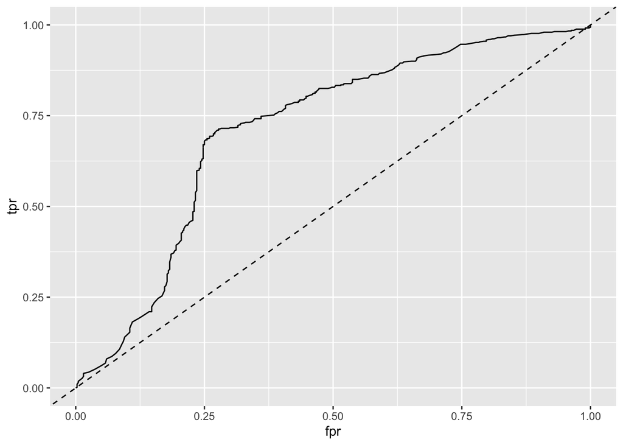

# model= rf filter= 0.1 outcome= hCG clin feat= g1+g2+g3

## Internal validation

|  | Accuracy | Sensitivity | Specificity | AUC |
| --- | --- | --- | --- | --- |
| metric.mean.df | 0.798 | 0.772 | 0.824 | 0.856 |
| metric.quantiles | (0.769-0.831) | (0.719-0.837) | (0.748-0.872) | (0.828-0.884) |

|  | Negative-reference | Positive-reference |
| --- | --- | --- |
| Negative-prediction | 272 | 73 |
| Positive-prediction | 58 | 247 |

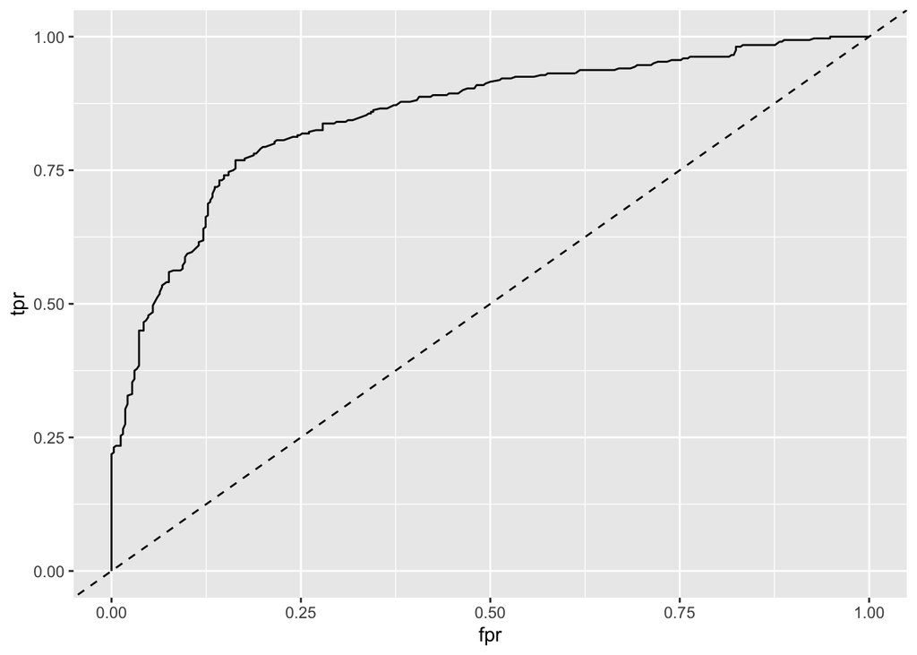

## External validation

|  | Accuracy | Sensitivity | Specificity | AUC |
| --- | --- | --- | --- | --- |
| metric.mean.df | 0.79 | 0.838 | 0.717 | 0.842 |
| metric.quantiles | (0.772-0.808) | (0.82-0.85) | (0.7-0.744) | (0.824-0.852) |

|  | Negative-reference | Positive-reference |
| --- | --- | --- |
| Negative-prediction | 287 | 97 |
| Positive-prediction | 113 | 503 |

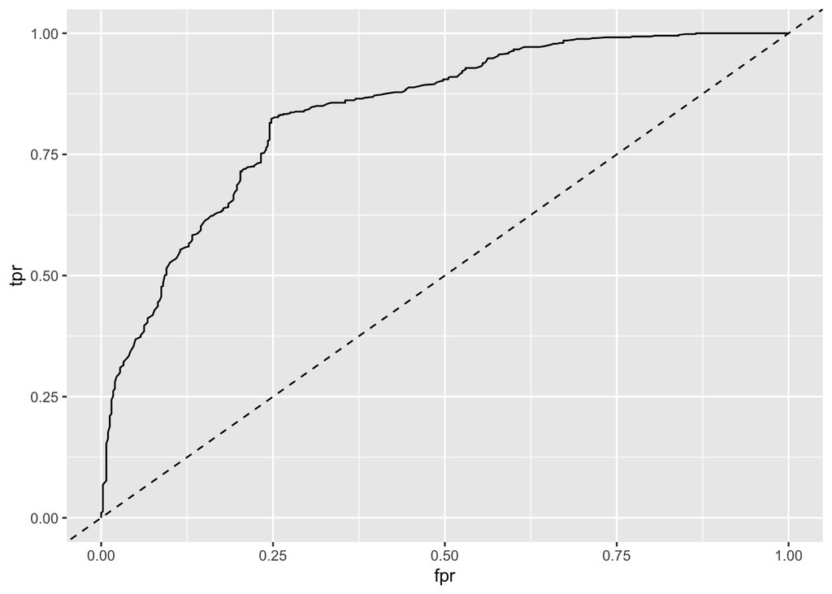

# model= rf filter= 0.1 outcome= hCG clin feat= g1+g2+g3+age

## Internal validation

|  | Accuracy | Sensitivity | Specificity | AUC |
| --- | --- | --- | --- | --- |
| metric.mean.df | 0.762 | 0.719 | 0.803 | 0.827 |
| metric.quantiles | (0.727-0.797) | (0.663-0.781) | (0.758-0.848) | (0.803-0.866) |

|  | Negative-reference | Positive-reference |
| --- | --- | --- |
| Negative-prediction | 265 | 90 |
| Positive-prediction | 65 | 230 |

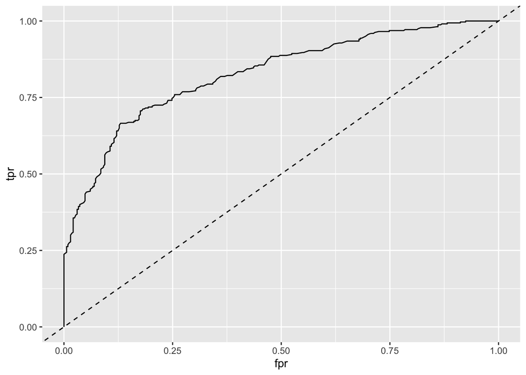

## External validation

|  | Accuracy | Sensitivity | Specificity | AUC |
| --- | --- | --- | --- | --- |
| metric.mean.df | 0.741 | 0.82 | 0.623 | 0.779 |
| metric.quantiles | (0.712-0.76) | (0.787-0.833) | (0.6-0.669) | (0.769-0.784) |

|  | Negative-reference | Positive-reference |
| --- | --- | --- |
| Negative-prediction | 249 | 108 |
| Positive-prediction | 151 | 492 |

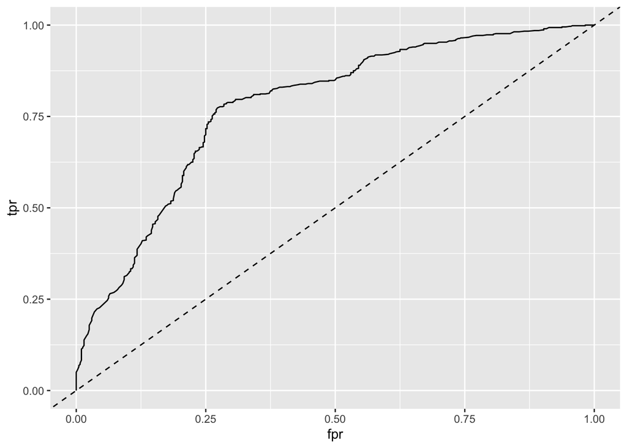

# model= rf filter= 0.1 outcome= hCG clin feat= g3

## Internal validation

|  | Accuracy | Sensitivity | Specificity | AUC |
| --- | --- | --- | --- | --- |
| metric.mean.df | 0.802 | 0.784 | 0.818 | 0.862 |
| metric.quantiles | (0.757-0.843) | (0.726-0.844) | (0.734-0.872) | (0.833-0.883) |

|  | Negative-reference | Positive-reference |
| --- | --- | --- |
| Negative-prediction | 270 | 69 |
| Positive-prediction | 60 | 251 |

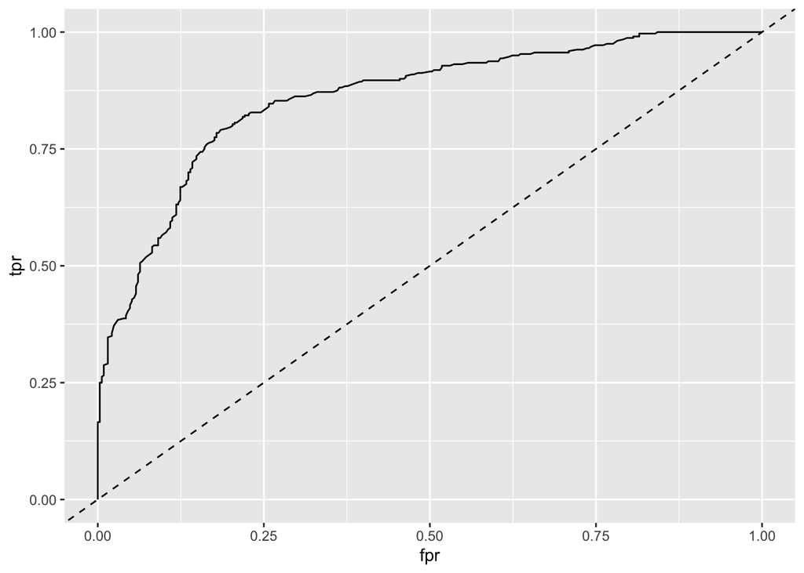

## External validation

|  | Accuracy | Sensitivity | Specificity | AUC |
| --- | --- | --- | --- | --- |
| metric.mean.df | 0.741 | 0.83 | 0.608 | 0.793 |
| metric.quantiles | (0.722-0.758) | (0.817-0.833) | (0.556-0.65) | (0.787-0.8) |

|  | Negative-reference | Positive-reference |
| --- | --- | --- |
| Negative-prediction | 243 | 102 |
| Positive-prediction | 157 | 498 |

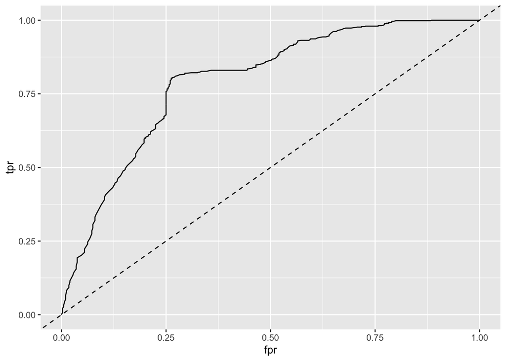

# model= rf filter= 0.1 outcome= hCG clin feat= g3+age

## Internal validation

|  | Accuracy | Sensitivity | Specificity | AUC |
| --- | --- | --- | --- | --- |
| metric.mean.df | 0.772 | 0.719 | 0.824 | 0.838 |
| metric.quantiles | (0.73-0.8) | (0.688-0.75) | (0.771-0.848) | (0.802-0.863) |

|  | Negative-reference | Positive-reference |
| --- | --- | --- |
| Negative-prediction | 272 | 90 |
| Positive-prediction | 58 | 230 |

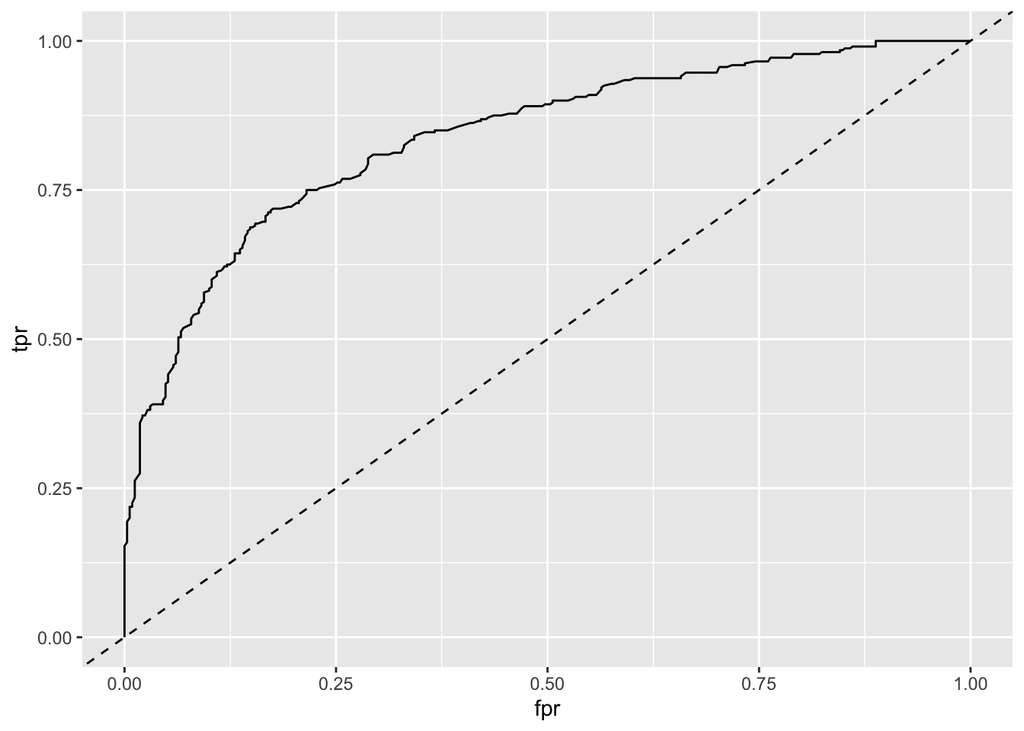

## External validation

|  | Accuracy | Sensitivity | Specificity | AUC |
| --- | --- | --- | --- | --- |
| metric.mean.df | 0.7 | 0.785 | 0.573 | 0.732 |
| metric.quantiles | (0.672-0.733) | (0.75-0.817) | (0.55-0.614) | (0.716-0.749) |

|  | Negative-reference | Positive-reference |
| --- | --- | --- |
| Negative-prediction | 229 | 129 |
| Positive-prediction | 171 | 471 |

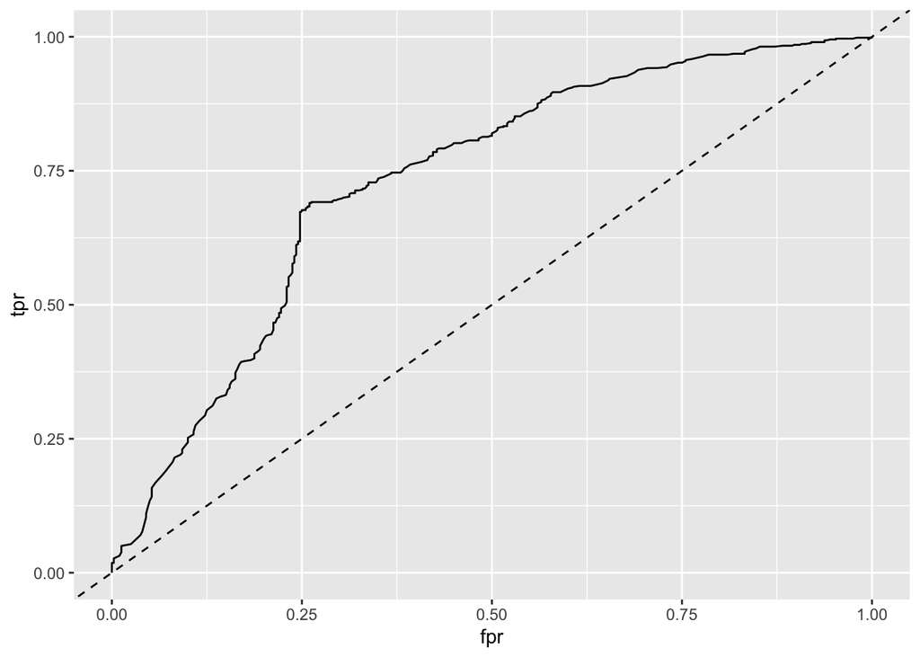

# model= rf filter= 0.05 outcome= lbo clin feat= none

## Internal validation

|  | Accuracy | Sensitivity | Specificity | AUC |
| --- | --- | --- | --- | --- |
| metric.mean.df | 0.751 | 0.642 | 0.823 | 0.801 |
| metric.quantiles | (0.657-0.797) | (0.547-0.692) | (0.71-0.912) | (0.748-0.843) |

|  | NPO-reference | Live_birth-reference |
| --- | --- | --- |
| NPO-prediction | 321 | 93 |
| Live_birth-prediction | 69 | 167 |

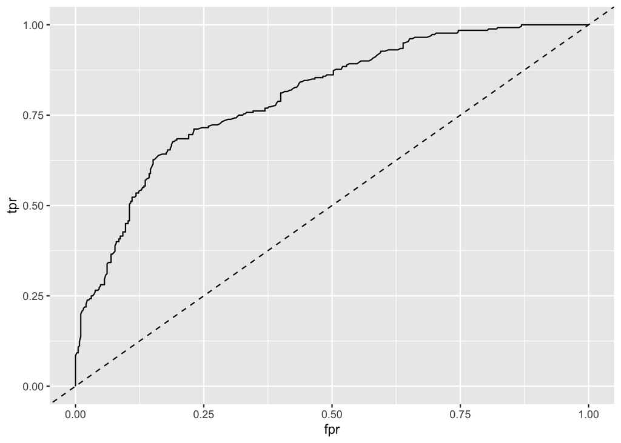

## External validation

|  | Accuracy | Sensitivity | Specificity | AUC |
| --- | --- | --- | --- | --- |
| metric.mean.df | 0.63 | 0.668 | 0.573 | 0.703 |
| metric.quantiles | (0.61-0.658) | (0.637-0.683) | (0.55-0.619) | (0.69-0.714) |

|  | NPO-reference | Live_birth-reference |
| --- | --- | --- |
| NPO-prediction | 229 | 199 |
| Live_birth-prediction | 171 | 401 |

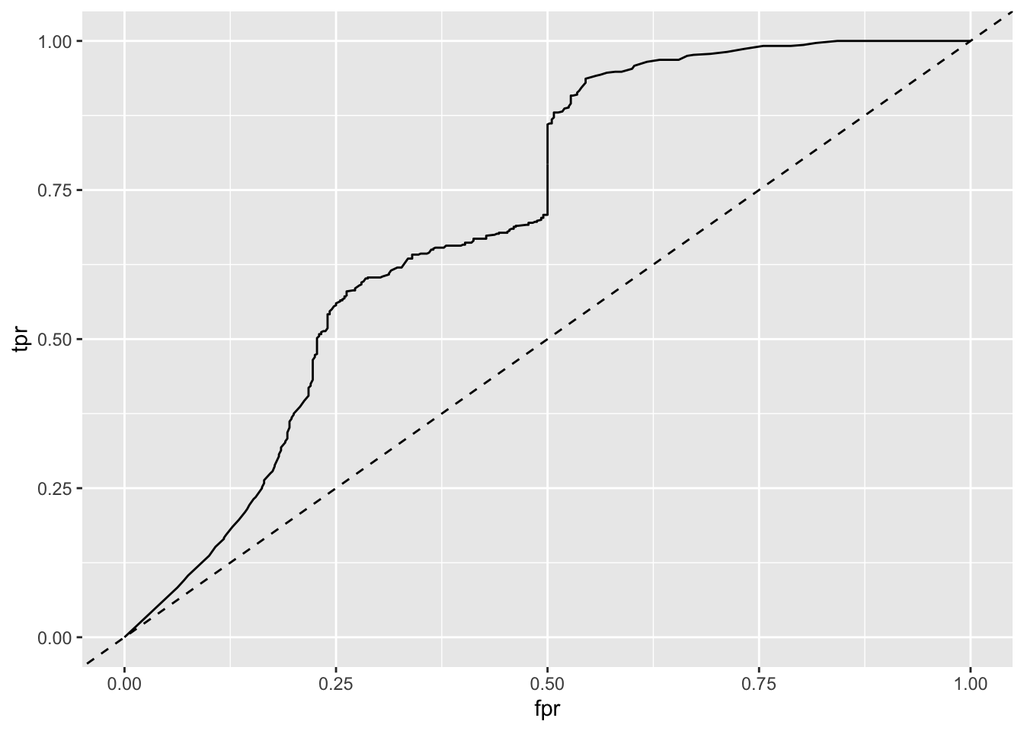

# model= rf filter= 0.05 outcome= lbo clin feat= age

## Internal validation

|  | Accuracy | Sensitivity | Specificity | AUC |
| --- | --- | --- | --- | --- |
| metric.mean.df | 0.745 | 0.615 | 0.831 | 0.789 |
| metric.quantiles | (0.699-0.781) | (0.577-0.654) | (0.775-0.886) | (0.758-0.816) |

|  | NPO-reference | Live_birth-reference |
| --- | --- | --- |
| NPO-prediction | 324 | 100 |
| Live_birth-prediction | 66 | 160 |

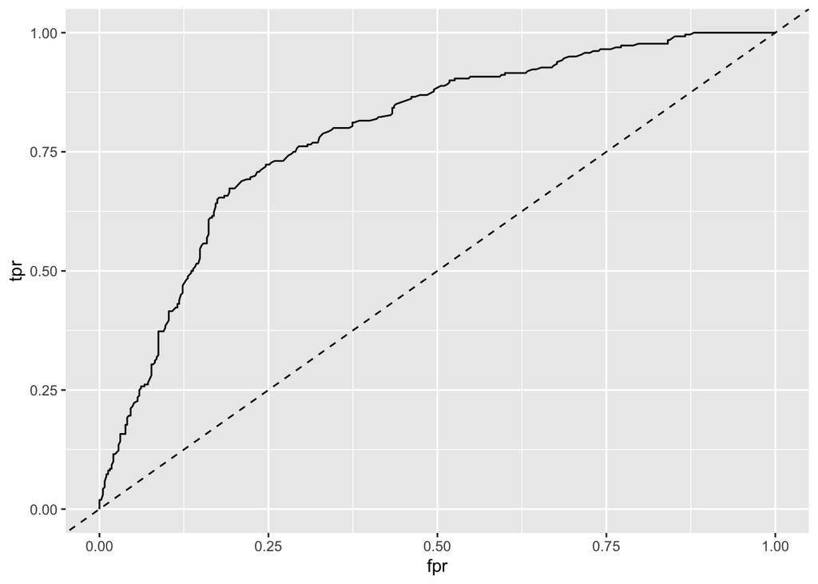

## External validation

|  | Accuracy | Sensitivity | Specificity | AUC |
| --- | --- | --- | --- | --- |
| metric.mean.df | 0.615 | 0.615 | 0.615 | 0.64 |
| metric.quantiles | (0.602-0.628) | (0.587-0.65) | (0.556-0.689) | (0.631-0.649) |

|  | NPO-reference | Live_birth-reference |
| --- | --- | --- |
| NPO-prediction | 246 | 231 |
| Live_birth-prediction | 154 | 369 |

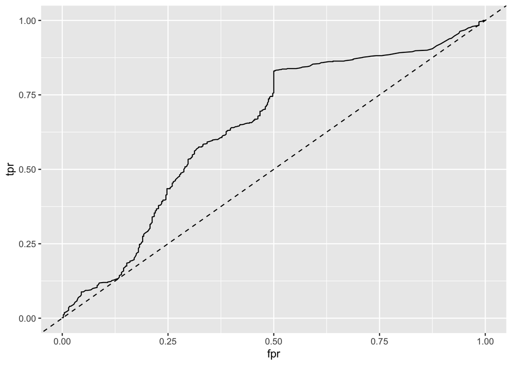

# model= rf filter= 0.05 outcome= lbo clin feat= g1+g2+g3

## Internal validation

|  | Accuracy | Sensitivity | Specificity | AUC |
| --- | --- | --- | --- | --- |
| metric.mean.df | 0.782 | 0.646 | 0.872 | 0.846 |
| metric.quantiles | (0.754-0.836) | (0.615-0.743) | (0.826-0.897) | (0.822-0.879) |

|  | NPO-reference | Live_birth-reference |
| --- | --- | --- |
| NPO-prediction | 340 | 92 |
| Live_birth-prediction | 50 | 168 |

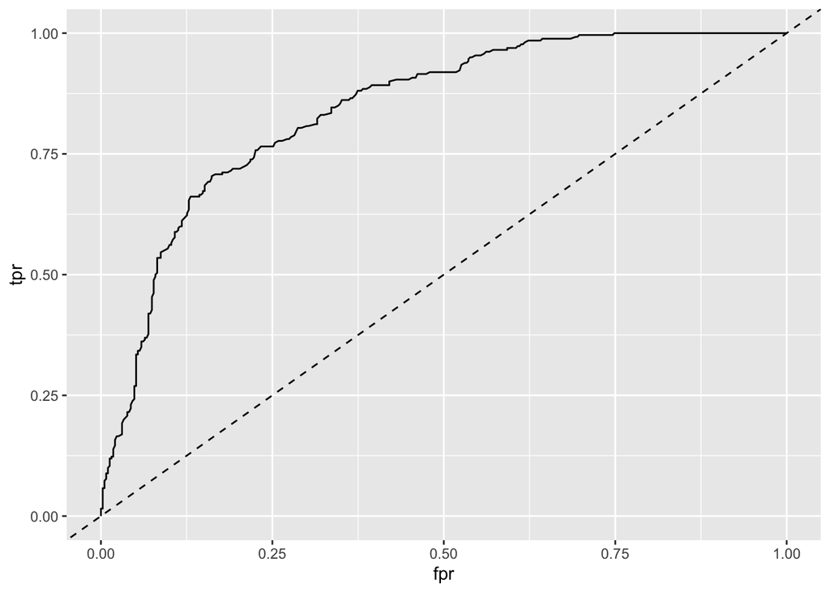

## External validation

|  | Accuracy | Sensitivity | Specificity | AUC |
| --- | --- | --- | --- | --- |
| metric.mean.df | 0.634 | 0.665 | 0.588 | 0.738 |
| metric.quantiles | (0.597-0.66) | (0.633-0.683) | (0.531-0.625) | (0.731-0.75) |

|  | NPO-reference | Live_birth-reference |
| --- | --- | --- |
| NPO-prediction | 235 | 201 |
| Live_birth-prediction | 165 | 399 |

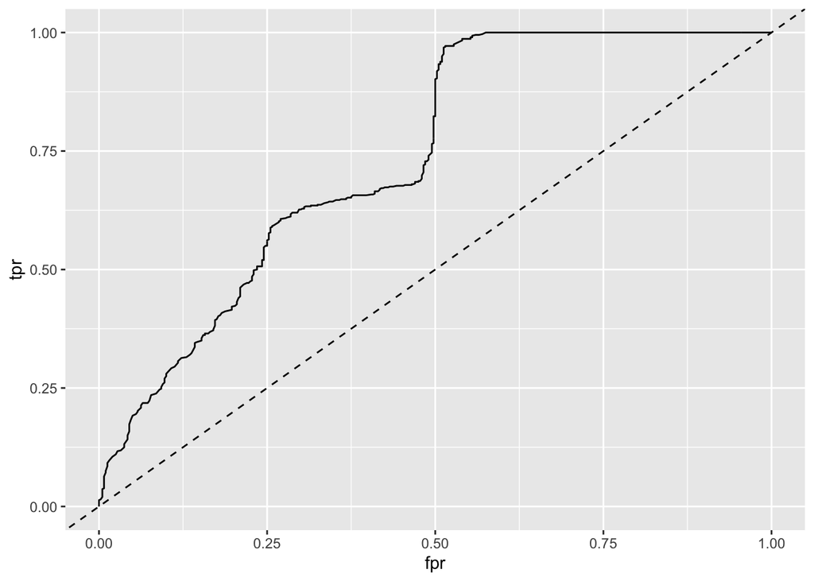

# model= rf filter= 0.05 outcome= lbo clin feat= g1+g2+g3+age

## Internal validation

|  | Accuracy | Sensitivity | Specificity | AUC |
| --- | --- | --- | --- | --- |
| metric.mean.df | 0.769 | 0.635 | 0.859 | 0.821 |
| metric.quantiles | (0.691-0.812) | (0.488-0.692) | (0.821-0.897) | (0.764-0.849) |

|  | NPO-reference | Live_birth-reference |
| --- | --- | --- |
| NPO-prediction | 335 | 95 |
| Live_birth-prediction | 55 | 165 |

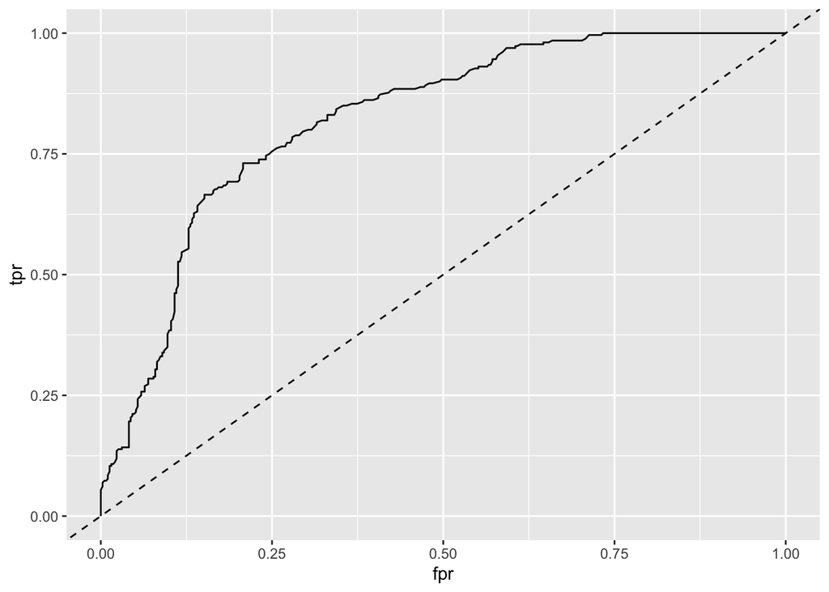

## External validation

|  | Accuracy | Sensitivity | Specificity | AUC |
| --- | --- | --- | --- | --- |
| metric.mean.df | 0.623 | 0.652 | 0.58 | 0.695 |
| metric.quantiles | (0.592-0.64) | (0.6-0.683) | (0.517-0.619) | (0.688-0.701) |

|  | NPO-reference | Live_birth-reference |
| --- | --- | --- |
| NPO-prediction | 232 | 209 |
| Live_birth-prediction | 168 | 391 |

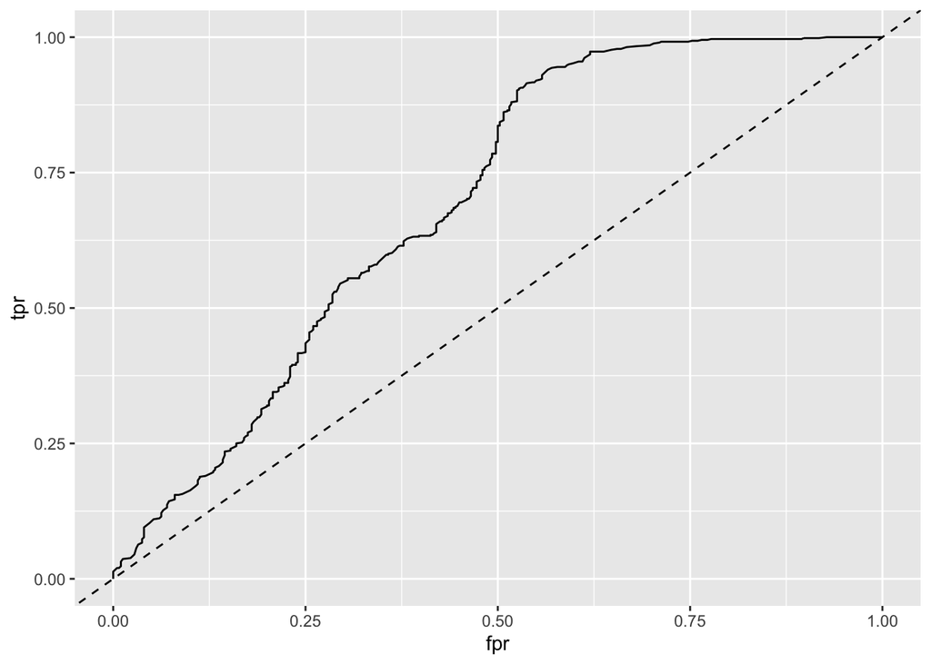

# model= rf filter= 0.05 outcome= lbo clin feat= g3

## Internal validation

|  | Accuracy | Sensitivity | Specificity | AUC |
| --- | --- | --- | --- | --- |
| metric.mean.df | 0.78 | 0.654 | 0.864 | 0.831 |
| metric.quantiles | (0.757-0.8) | (0.615-0.692) | (0.801-0.897) | (0.816-0.848) |

|  | NPO-reference | Live_birth-reference |
| --- | --- | --- |
| NPO-prediction | 337 | 90 |
| Live_birth-prediction | 53 | 170 |

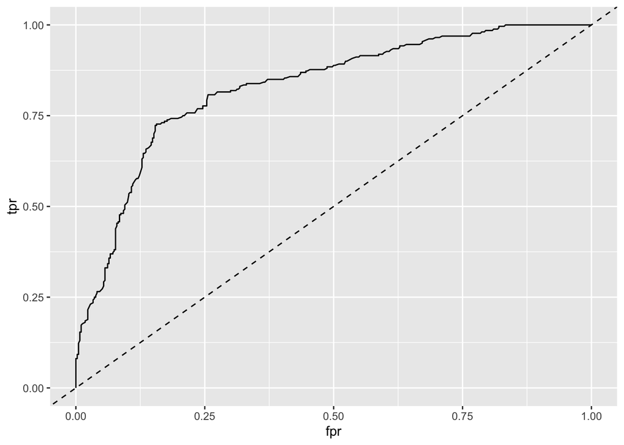

## External validation

|  | Accuracy | Sensitivity | Specificity | AUC |
| --- | --- | --- | --- | --- |
| metric.mean.df | 0.636 | 0.662 | 0.597 | 0.706 |
| metric.quantiles | (0.6-0.658) | (0.62-0.683) | (0.556-0.65) | (0.699-0.716) |

|  | NPO-reference | Live_birth-reference |
| --- | --- | --- |
| NPO-prediction | 239 | 203 |
| Live_birth-prediction | 161 | 397 |

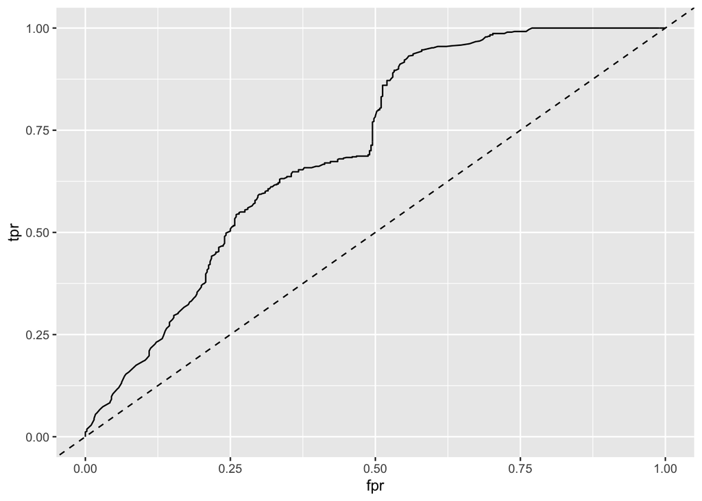

# model= rf filter= 0.05 outcome= lbo clin feat= g3+age

## Internal validation

|  | Accuracy | Sensitivity | Specificity | AUC |
| --- | --- | --- | --- | --- |
| metric.mean.df | 0.774 | 0.642 | 0.862 | 0.816 |
| metric.quantiles | (0.715-0.812) | (0.526-0.692) | (0.806-0.892) | (0.783-0.835) |

|  | NPO-reference | Live_birth-reference |
| --- | --- | --- |
| NPO-prediction | 336 | 93 |
| Live_birth-prediction | 54 | 167 |

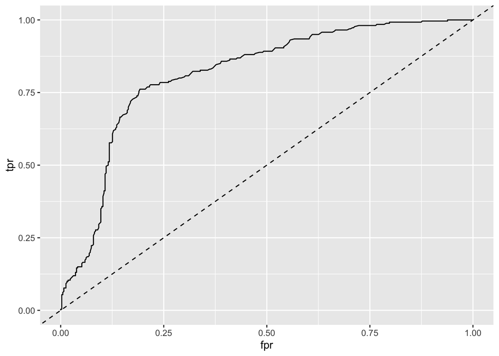

## External validation

|  | Accuracy | Sensitivity | Specificity | AUC |
| --- | --- | --- | --- | --- |
| metric.mean.df | 0.622 | 0.622 | 0.622 | 0.664 |
| metric.quantiles | (0.6-0.656) | (0.583-0.663) | (0.536-0.694) | (0.659-0.669) |

|  | NPO-reference | Live_birth-reference |
| --- | --- | --- |
| NPO-prediction | 249 | 227 |
| Live_birth-prediction | 151 | 373 |

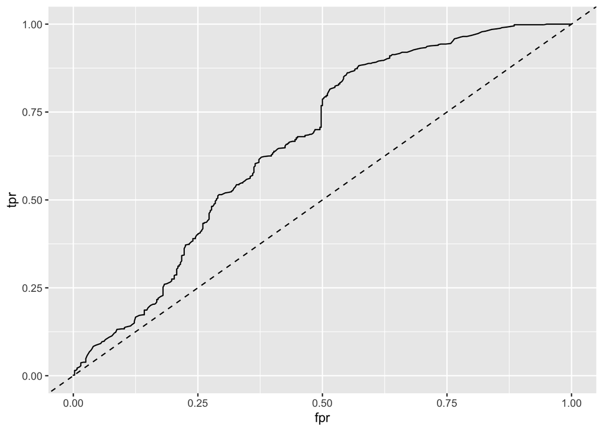

# model= rf filter= 0.1 outcome= lbo clin feat= none

## Internal validation

|  | Accuracy | Sensitivity | Specificity | AUC |
| --- | --- | --- | --- | --- |
| metric.mean.df | 0.706 | 0.585 | 0.787 | 0.75 |
| metric.quantiles | (0.65-0.75) | (0.509-0.645) | (0.704-0.846) | (0.686-0.787) |

|  | NPO-reference | Live_birth-reference |
| --- | --- | --- |
| NPO-prediction | 307 | 108 |
| Live_birth-prediction | 83 | 152 |

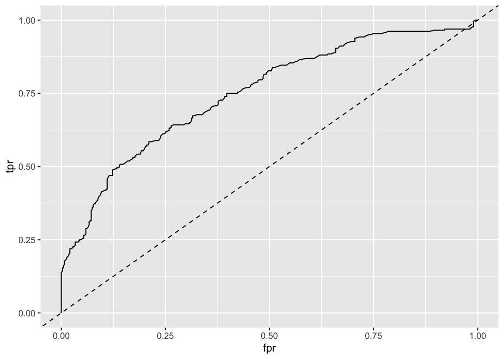

## External validation

|  | Accuracy | Sensitivity | Specificity | AUC |
| --- | --- | --- | --- | --- |
| metric.mean.df | 0.779 | 0.813 | 0.727 | 0.718 |
| metric.quantiles | (0.762-0.798) | (0.787-0.833) | (0.725-0.744) | (0.71-0.728) |

|  | NPO-reference | Live_birth-reference |
| --- | --- | --- |
| NPO-prediction | 291 | 112 |
| Live_birth-prediction | 109 | 488 |

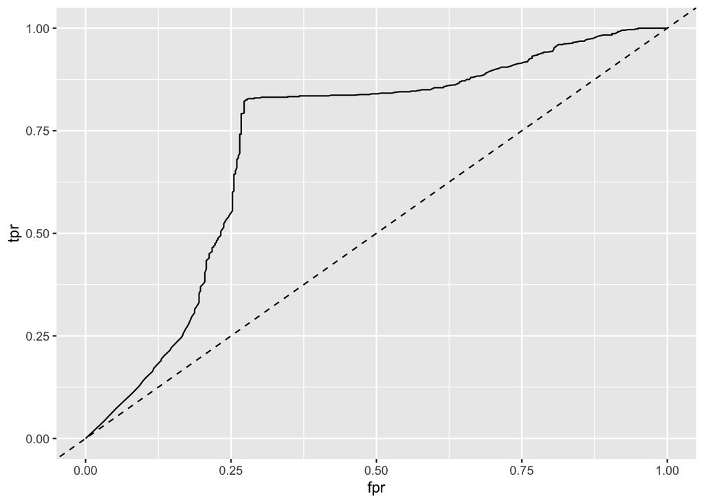

# model= rf filter= 0.1 outcome= lbo clin feat= age

## Internal validation

|  | Accuracy | Sensitivity | Specificity | AUC |
| --- | --- | --- | --- | --- |
| metric.mean.df | 0.694 | 0.569 | 0.777 | 0.732 |
| metric.quantiles | (0.65-0.735) | (0.538-0.615) | (0.724-0.835) | (0.674-0.766) |

|  | NPO-reference | Live_birth-reference |
| --- | --- | --- |
| NPO-prediction | 303 | 112 |
| Live_birth-prediction | 87 | 148 |

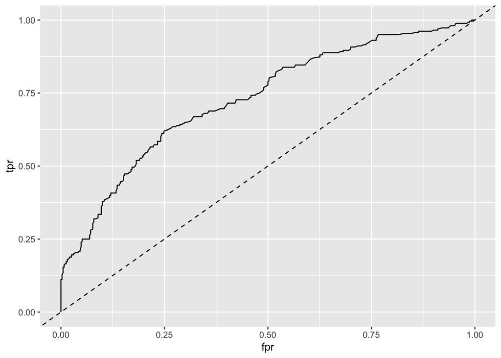

## External validation

|  | Accuracy | Sensitivity | Specificity | AUC |
| --- | --- | --- | --- | --- |
| metric.mean.df | 0.778 | 0.81 | 0.73 | 0.667 |
| metric.quantiles | (0.76-0.798) | (0.783-0.833) | (0.725-0.75) | (0.658-0.676) |

|  | NPO-reference | Live_birth-reference |
| --- | --- | --- |
| NPO-prediction | 292 | 114 |
| Live_birth-prediction | 108 | 486 |

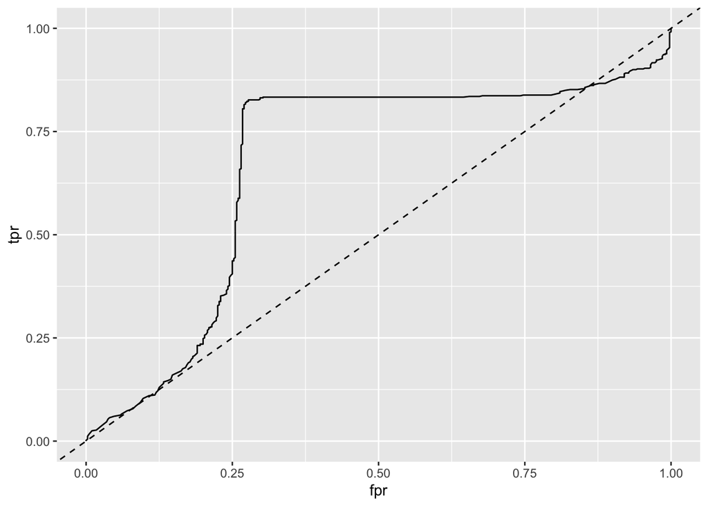

# model= rf filter= 0.1 outcome= lbo clin feat= g1+g2+g3

## Internal validation

|  | Accuracy | Sensitivity | Specificity | AUC |
| --- | --- | --- | --- | --- |
| metric.mean.df | 0.729 | 0.612 | 0.808 | 0.779 |
| metric.quantiles | (0.708-0.754) | (0.577-0.684) | (0.775-0.846) | (0.763-0.805) |

|  | NPO-reference | Live_birth-reference |
| --- | --- | --- |
| NPO-prediction | 315 | 101 |
| Live_birth-prediction | 75 | 159 |

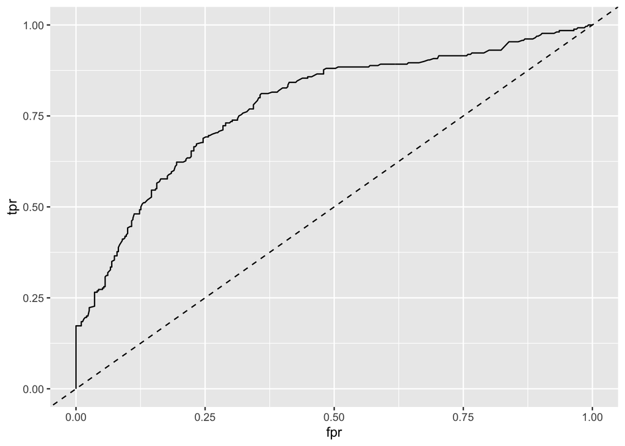

## External validation

|  | Accuracy | Sensitivity | Specificity | AUC |
| --- | --- | --- | --- | --- |
| metric.mean.df | 0.782 | 0.818 | 0.727 | 0.771 |
| metric.quantiles | (0.77-0.79) | (0.8-0.833) | (0.725-0.744) | (0.76-0.783) |

|  | NPO-reference | Live_birth-reference |
| --- | --- | --- |
| NPO-prediction | 291 | 109 |
| Live_birth-prediction | 109 | 491 |

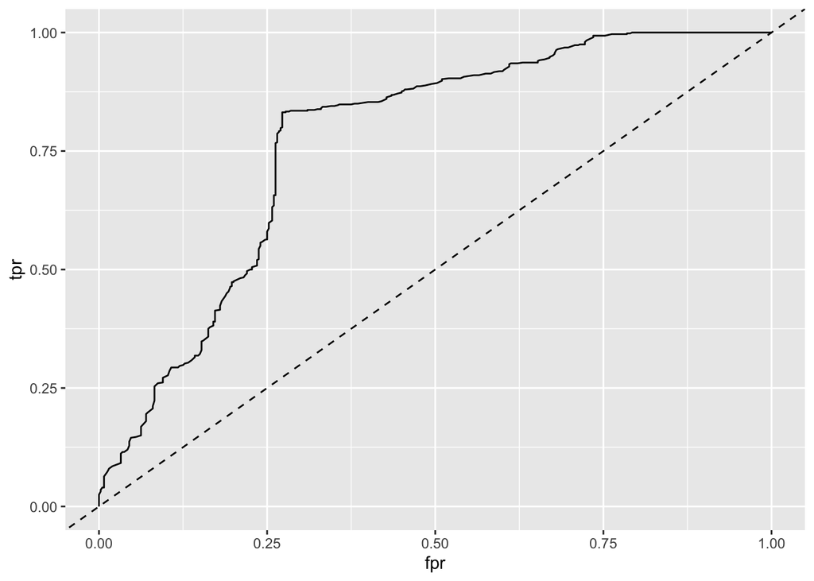

# model= rf filter= 0.1 outcome= lbo clin feat= g1+g2+g3+age

## Internal validation

|  | Accuracy | Sensitivity | Specificity | AUC |
| --- | --- | --- | --- | --- |
| metric.mean.df | 0.725 | 0.604 | 0.805 | 0.758 |
| metric.quantiles | (0.665-0.766) | (0.547-0.654) | (0.71-0.866) | (0.724-0.78) |

|  | NPO-reference | Live_birth-reference |
| --- | --- | --- |
| NPO-prediction | 314 | 103 |
| Live_birth-prediction | 76 | 157 |

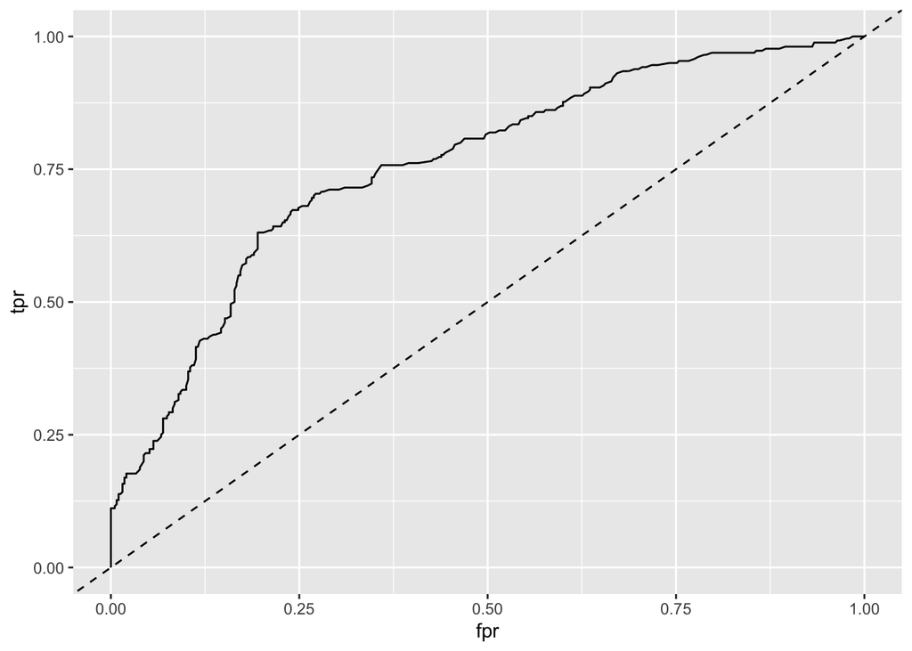

## External validation

|  | Accuracy | Sensitivity | Specificity | AUC |
| --- | --- | --- | --- | --- |
| metric.mean.df | 0.782 | 0.815 | 0.732 | 0.717 |
| metric.quantiles | (0.762-0.79) | (0.787-0.833) | (0.725-0.75) | (0.706-0.728) |

|  | NPO-reference | Live_birth-reference |
| --- | --- | --- |
| NPO-prediction | 293 | 111 |
| Live_birth-prediction | 107 | 489 |

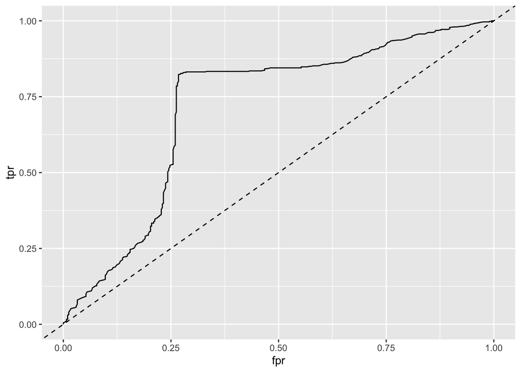

# model= rf filter= 0.1 outcome= lbo clin feat= g3

## Internal validation

|  | Accuracy | Sensitivity | Specificity | AUC |
| --- | --- | --- | --- | --- |
| metric.mean.df | 0.723 | 0.619 | 0.792 | 0.768 |
| metric.quantiles | (0.66-0.766) | (0.547-0.722) | (0.729-0.84) | (0.748-0.787) |

|  | NPO-reference | Live_birth-reference |
| --- | --- | --- |
| NPO-prediction | 309 | 99 |
| Live_birth-prediction | 81 | 161 |

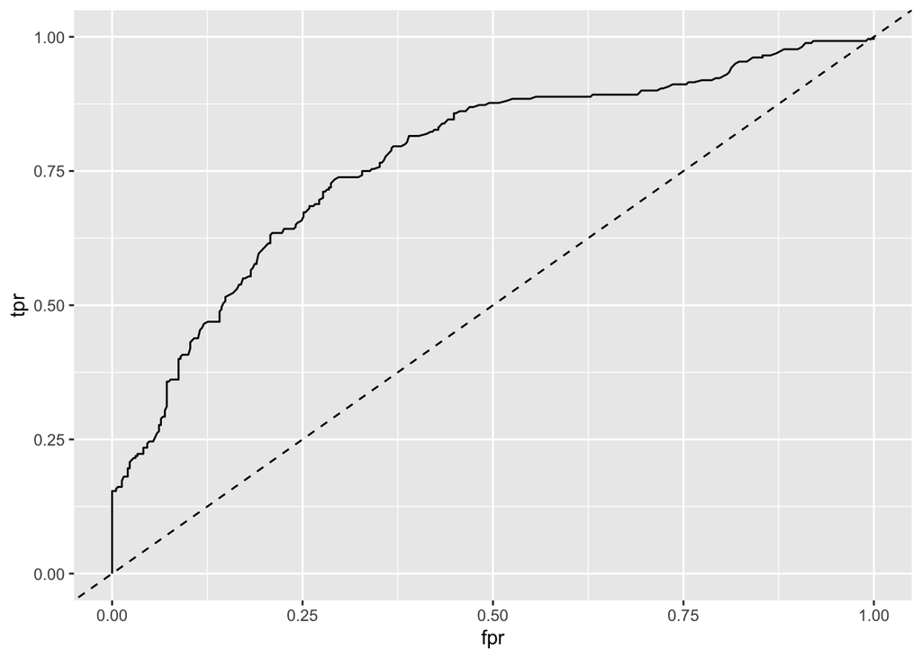

## External validation

|  | Accuracy | Sensitivity | Specificity | AUC |
| --- | --- | --- | --- | --- |
| metric.mean.df | 0.762 | 0.782 | 0.732 | 0.744 |
| metric.quantiles | (0.742-0.778) | (0.75-0.813) | (0.706-0.75) | (0.738-0.752) |

|  | NPO-reference | Live_birth-reference |
| --- | --- | --- |
| NPO-prediction | 293 | 131 |
| Live_birth-prediction | 107 | 469 |

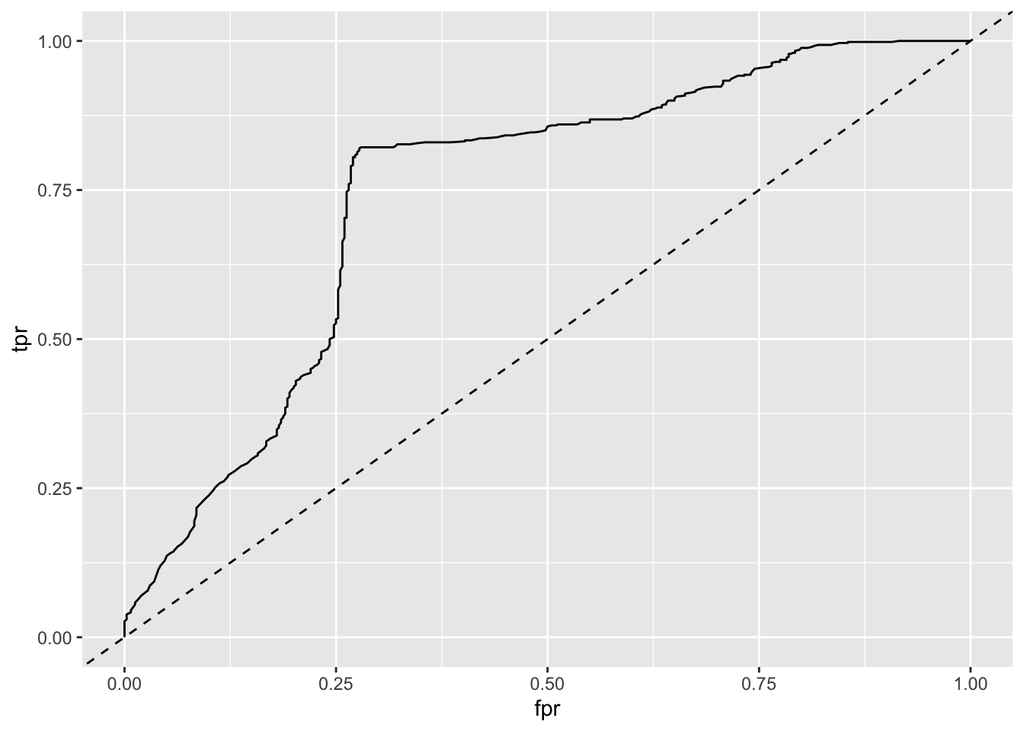

# model= rf filter= 0.1 outcome= lbo clin feat= g3+age

## Internal validation

|  | Accuracy | Sensitivity | Specificity | AUC |
| --- | --- | --- | --- | --- |
| metric.mean.df | 0.717 | 0.565 | 0.818 | 0.759 |
| metric.quantiles | (0.68-0.754) | (0.538-0.615) | (0.749-0.872) | (0.733-0.787) |

|  | NPO-reference | Live_birth-reference |
| --- | --- | --- |
| NPO-prediction | 319 | 113 |
| Live_birth-prediction | 71 | 147 |

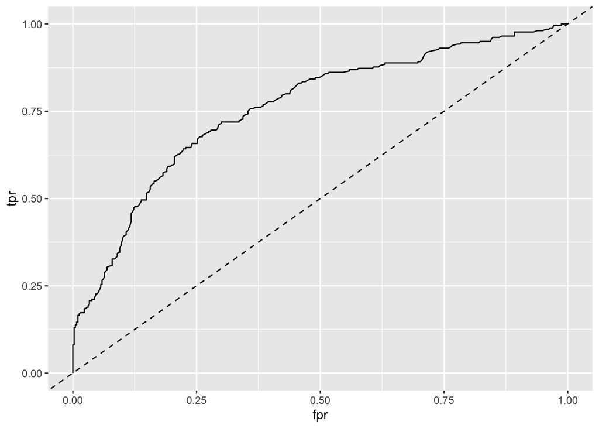

## External validation

|  | Accuracy | Sensitivity | Specificity | AUC |
| --- | --- | --- | --- | --- |
| metric.mean.df | 0.775 | 0.808 | 0.725 | 0.693 |
| metric.quantiles | (0.754-0.798) | (0.783-0.833) | (0.7-0.75) | (0.676-0.704) |

|  | NPO-reference | Live_birth-reference |
| --- | --- | --- |
| NPO-prediction | 290 | 115 |
| Live_birth-prediction | 110 | 485 |

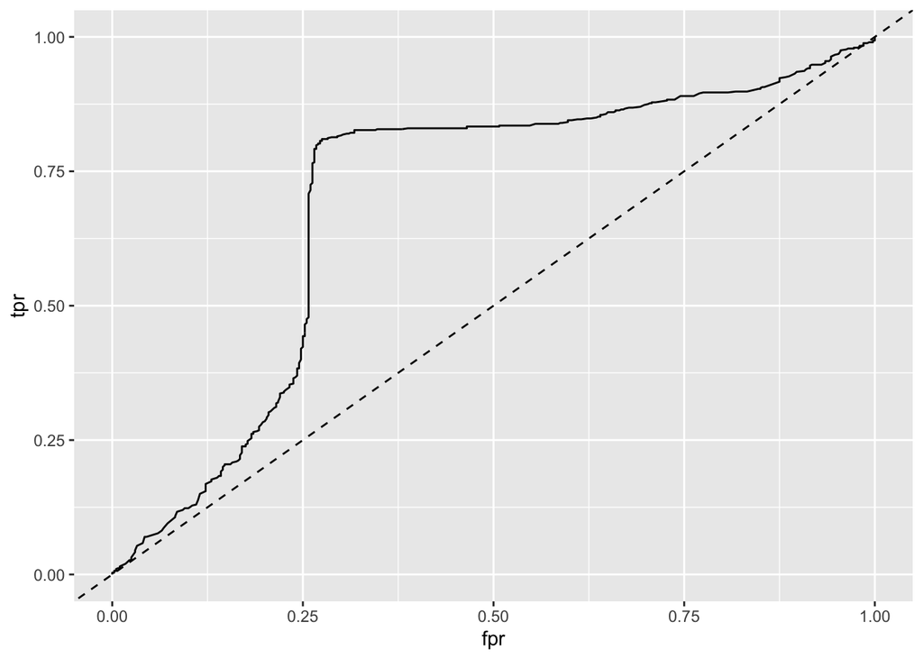

# Features

## 0.05 filter

```
##  [1] "PABPC4"   "RPS19"    "MACF1"    "MED18"    "PSMD4"    "JMJD1C"
##  [7] "H1-5"     "HMGB1P10" "RN7SL4P"  "RN7SL1"
```

## 0.1 filter

```
##  [1] "SMC1A"    "NDUFB2"   "PABPC4"   "RPS19"    "G3BP2"    "PSMD4"
##  [7] "NOLC1"    "H1-5"     "RNVU1-7"  "HMGB1P10" "RN7SL4P"  "RN7SL1"
```

# Summary

## Internal validation

| Name | Accuracy | Sensitivity | Specificity | AUC |
| --- | --- | --- | --- | --- |
| model-ridge_filt-0.05_class-hCG_clin.feat- | 0.786 | 0.822 | 0.752 | 0.874 |
| model-ridge_filt-0.05_class-hCG_clin.feat-age | 0.802 | 0.822 | 0.782 | 0.879 |
| model-ridge_filt-0.05_class-hCG_clin.feat-g1+g2+g3 | 0.743 | 0.741 | 0.745 | 0.841 |
| model-ridge_filt-0.05_class-hCG_clin.feat-g1+g2+g3+age | 0.772 | 0.778 | 0.767 | 0.852 |
| model-ridge_filt-0.05_class-hCG_clin.feat-g3 | 0.766 | 0.794 | 0.739 | 0.858 |
| model-ridge_filt-0.05_class-hCG_clin.feat-g3+age | 0.788 | 0.822 | 0.755 | 0.865 |
| model-ridge_filt-0.1_class-hCG_clin.feat- | 0.798 | 0.794 | 0.803 | 0.876 |
| model-ridge_filt-0.1_class-hCG_clin.feat-age | 0.782 | 0.775 | 0.788 | 0.869 |
| model-ridge_filt-0.1_class-hCG_clin.feat-g1+g2+g3 | 0.809 | 0.812 | 0.806 | 0.859 |
| model-ridge_filt-0.1_class-hCG_clin.feat-g1+g2+g3+age | 0.789 | 0.791 | 0.788 | 0.855 |
| model-ridge_filt-0.1_class-hCG_clin.feat-g3 | 0.814 | 0.812 | 0.815 | 0.867 |
| model-ridge_filt-0.1_class-hCG_clin.feat-g3+age | 0.809 | 0.797 | 0.821 | 0.86 |
| model-ridge_filt-0.05_class-lbo_clin.feat- | 0.749 | 0.615 | 0.838 | 0.814 |
| model-ridge_filt-0.05_class-lbo_clin.feat-age | 0.729 | 0.588 | 0.823 | 0.817 |
| model-ridge_filt-0.05_class-lbo_clin.feat-g1+g2+g3 | 0.749 | 0.623 | 0.833 | 0.83 |
| model-ridge_filt-0.05_class-lbo_clin.feat-g1+g2+g3+age | 0.74 | 0.604 | 0.831 | 0.833 |
| model-ridge_filt-0.05_class-lbo_clin.feat-g3 | 0.757 | 0.669 | 0.815 | 0.837 |
| model-ridge_filt-0.05_class-lbo_clin.feat-g3+age | 0.768 | 0.658 | 0.841 | 0.836 |
| model-ridge_filt-0.1_class-lbo_clin.feat- | 0.749 | 0.577 | 0.864 | 0.78 |
| model-ridge_filt-0.1_class-lbo_clin.feat-age | 0.729 | 0.573 | 0.833 | 0.769 |
| model-ridge_filt-0.1_class-lbo_clin.feat-g1+g2+g3 | 0.731 | 0.585 | 0.828 | 0.784 |
| model-ridge_filt-0.1_class-lbo_clin.feat-g1+g2+g3+age | 0.725 | 0.558 | 0.836 | 0.781 |
| model-ridge_filt-0.1_class-lbo_clin.feat-g3 | 0.794 | 0.746 | 0.826 | 0.787 |
| model-ridge_filt-0.1_class-lbo_clin.feat-g3+age | 0.772 | 0.696 | 0.823 | 0.785 |
| model-rf_filt-0.05_class-hCG_clin.feat- | 0.726 | 0.719 | 0.733 | 0.821 |
| model-rf_filt-0.05_class-hCG_clin.feat-age | 0.726 | 0.728 | 0.724 | 0.814 |
| model-rf_filt-0.05_class-hCG_clin.feat-g1+g2+g3 | 0.775 | 0.778 | 0.773 | 0.841 |
| model-rf_filt-0.05_class-hCG_clin.feat-g1+g2+g3+age | 0.765 | 0.756 | 0.773 | 0.813 |
| model-rf_filt-0.05_class-hCG_clin.feat-g3 | 0.765 | 0.8 | 0.73 | 0.841 |
| model-rf_filt-0.05_class-hCG_clin.feat-g3+age | 0.757 | 0.753 | 0.761 | 0.814 |
| model-rf_filt-0.1_class-hCG_clin.feat- | 0.8 | 0.784 | 0.815 | 0.867 |
| model-rf_filt-0.1_class-hCG_clin.feat-age | 0.749 | 0.719 | 0.779 | 0.835 |
| model-rf_filt-0.1_class-hCG_clin.feat-g1+g2+g3 | 0.798 | 0.772 | 0.824 | 0.856 |
| model-rf_filt-0.1_class-hCG_clin.feat-g1+g2+g3+age | 0.762 | 0.719 | 0.803 | 0.827 |
| model-rf_filt-0.1_class-hCG_clin.feat-g3 | 0.802 | 0.784 | 0.818 | 0.862 |
| model-rf_filt-0.1_class-hCG_clin.feat-g3+age | 0.772 | 0.719 | 0.824 | 0.838 |
| model-rf_filt-0.05_class-lbo_clin.feat- | 0.751 | 0.642 | 0.823 | 0.801 |
| model-rf_filt-0.05_class-lbo_clin.feat-age | 0.745 | 0.615 | 0.831 | 0.789 |
| model-rf_filt-0.05_class-lbo_clin.feat-g1+g2+g3 | 0.782 | 0.646 | 0.872 | 0.846 |
| model-rf_filt-0.05_class-lbo_clin.feat-g1+g2+g3+age | 0.769 | 0.635 | 0.859 | 0.821 |
| model-rf_filt-0.05_class-lbo_clin.feat-g3 | 0.78 | 0.654 | 0.864 | 0.831 |
| model-rf_filt-0.05_class-lbo_clin.feat-g3+age | 0.774 | 0.642 | 0.862 | 0.816 |
| model-rf_filt-0.1_class-lbo_clin.feat- | 0.706 | 0.585 | 0.787 | 0.75 |
| model-rf_filt-0.1_class-lbo_clin.feat-age | 0.694 | 0.569 | 0.777 | 0.732 |
| model-rf_filt-0.1_class-lbo_clin.feat-g1+g2+g3 | 0.729 | 0.612 | 0.808 | 0.779 |
| model-rf_filt-0.1_class-lbo_clin.feat-g1+g2+g3+age | 0.725 | 0.604 | 0.805 | 0.758 |
| model-rf_filt-0.1_class-lbo_clin.feat-g3 | 0.723 | 0.619 | 0.792 | 0.768 |
| model-rf_filt-0.1_class-lbo_clin.feat-g3+age | 0.717 | 0.565 | 0.818 | 0.759 |

## External validation

| Name | Accuracy | Sensitivity | Specificity | AUC |
| --- | --- | --- | --- | --- |
| model-ridge_filt-0.05_class-hCG_clin.feat- | 0.677 | 0.623 | 0.758 | 0.812 |
| model-ridge_filt-0.05_class-hCG_clin.feat-age | 0.646 | 0.572 | 0.758 | 0.806 |
| model-ridge_filt-0.05_class-hCG_clin.feat-g1+g2+g3 | 0.69 | 0.65 | 0.75 | 0.841 |
| model-ridge_filt-0.05_class-hCG_clin.feat-g1+g2+g3+age | 0.674 | 0.623 | 0.75 | 0.809 |
| model-ridge_filt-0.05_class-hCG_clin.feat-g3 | 0.72 | 0.7 | 0.75 | 0.779 |
| model-ridge_filt-0.05_class-hCG_clin.feat-g3+age | 0.682 | 0.637 | 0.75 | 0.774 |
| model-ridge_filt-0.1_class-hCG_clin.feat- | 0.713 | 0.835 | 0.53 | 0.744 |
| model-ridge_filt-0.1_class-hCG_clin.feat-age | 0.696 | 0.825 | 0.503 | 0.701 |
| model-ridge_filt-0.1_class-hCG_clin.feat-g1+g2+g3 | 0.746 | 0.86 | 0.575 | 0.811 |
| model-ridge_filt-0.1_class-hCG_clin.feat-g1+g2+g3+age | 0.718 | 0.853 | 0.515 | 0.766 |
| model-ridge_filt-0.1_class-hCG_clin.feat-g3 | 0.726 | 0.865 | 0.518 | 0.71 |
| model-ridge_filt-0.1_class-hCG_clin.feat-g3+age | 0.698 | 0.83 | 0.5 | 0.673 |
| model-ridge_filt-0.05_class-lbo_clin.feat- | 0.66 | 0.595 | 0.758 | 0.737 |
| model-ridge_filt-0.05_class-lbo_clin.feat-age | 0.649 | 0.572 | 0.765 | 0.743 |
| model-ridge_filt-0.05_class-lbo_clin.feat-g1+g2+g3 | 0.529 | 0.382 | 0.75 | 0.733 |
| model-ridge_filt-0.05_class-lbo_clin.feat-g1+g2+g3+age | 0.54 | 0.4 | 0.75 | 0.715 |
| model-ridge_filt-0.05_class-lbo_clin.feat-g3 | 0.561 | 0.435 | 0.75 | 0.742 |
| model-ridge_filt-0.05_class-lbo_clin.feat-g3+age | 0.564 | 0.44 | 0.75 | 0.725 |
| model-ridge_filt-0.1_class-lbo_clin.feat- | 0.794 | 0.823 | 0.75 | 0.748 |
| model-ridge_filt-0.1_class-lbo_clin.feat-age | 0.748 | 0.747 | 0.75 | 0.752 |
| model-ridge_filt-0.1_class-lbo_clin.feat-g1+g2+g3 | 0.667 | 0.62 | 0.737 | 0.722 |
| model-ridge_filt-0.1_class-lbo_clin.feat-g1+g2+g3+age | 0.635 | 0.583 | 0.713 | 0.712 |
| model-ridge_filt-0.1_class-lbo_clin.feat-g3 | 0.729 | 0.743 | 0.708 | 0.717 |
| model-ridge_filt-0.1_class-lbo_clin.feat-g3+age | 0.685 | 0.705 | 0.655 | 0.69 |
| model-rf_filt-0.05_class-hCG_clin.feat- | 0.721 | 0.815 | 0.58 | 0.735 |
| model-rf_filt-0.05_class-hCG_clin.feat-age | 0.666 | 0.722 | 0.583 | 0.683 |
| model-rf_filt-0.05_class-hCG_clin.feat-g1+g2+g3 | 0.749 | 0.828 | 0.63 | 0.809 |
| model-rf_filt-0.05_class-hCG_clin.feat-g1+g2+g3+age | 0.726 | 0.805 | 0.607 | 0.745 |
| model-rf_filt-0.05_class-hCG_clin.feat-g3 | 0.732 | 0.817 | 0.605 | 0.757 |
| model-rf_filt-0.05_class-hCG_clin.feat-g3+age | 0.675 | 0.738 | 0.58 | 0.704 |
| model-rf_filt-0.1_class-hCG_clin.feat- | 0.768 | 0.828 | 0.677 | 0.755 |
| model-rf_filt-0.1_class-hCG_clin.feat-age | 0.7 | 0.788 | 0.568 | 0.711 |
| model-rf_filt-0.1_class-hCG_clin.feat-g1+g2+g3 | 0.79 | 0.838 | 0.717 | 0.842 |
| model-rf_filt-0.1_class-hCG_clin.feat-g1+g2+g3+age | 0.741 | 0.82 | 0.623 | 0.779 |
| model-rf_filt-0.1_class-hCG_clin.feat-g3 | 0.741 | 0.83 | 0.608 | 0.793 |
| model-rf_filt-0.1_class-hCG_clin.feat-g3+age | 0.7 | 0.785 | 0.573 | 0.732 |
| model-rf_filt-0.05_class-lbo_clin.feat- | 0.63 | 0.668 | 0.573 | 0.703 |
| model-rf_filt-0.05_class-lbo_clin.feat-age | 0.615 | 0.615 | 0.615 | 0.64 |
| model-rf_filt-0.05_class-lbo_clin.feat-g1+g2+g3 | 0.634 | 0.665 | 0.588 | 0.738 |
| model-rf_filt-0.05_class-lbo_clin.feat-g1+g2+g3+age | 0.623 | 0.652 | 0.58 | 0.695 |
| model-rf_filt-0.05_class-lbo_clin.feat-g3 | 0.636 | 0.662 | 0.597 | 0.706 |
| model-rf_filt-0.05_class-lbo_clin.feat-g3+age | 0.622 | 0.622 | 0.622 | 0.664 |
| model-rf_filt-0.1_class-lbo_clin.feat- | 0.779 | 0.813 | 0.727 | 0.718 |
| model-rf_filt-0.1_class-lbo_clin.feat-age | 0.778 | 0.81 | 0.73 | 0.667 |
| model-rf_filt-0.1_class-lbo_clin.feat-g1+g2+g3 | 0.782 | 0.818 | 0.727 | 0.771 |
| model-rf_filt-0.1_class-lbo_clin.feat-g1+g2+g3+age | 0.782 | 0.815 | 0.732 | 0.717 |
| model-rf_filt-0.1_class-lbo_clin.feat-g3 | 0.762 | 0.782 | 0.732 | 0.744 |
| model-rf_filt-0.1_class-lbo_clin.feat-g3+age | 0.775 | 0.808 | 0.725 | 0.693 |